# Data Science Internship Exam

```python
#df12 = df11
#df12.head()
```

```python
df12 = df11.dropna(axis='columns')
df12
```

|  | BORO_x | BLOCK | LOT | SECVOL_x | DISTRICT_x | YEAR4_x | CUR_FV_L_x | CUR_FV_T_x | NEW_FV_L_x | NEW_FV_T_x | FV_CHGDT_x | CURAVL_x | CURAVT_x | CUREXL_x | CUREXT_x | CURAVL_A_x | CURAVT_A_x | CUREXL_A_x | CUREXT_A_x | CHGDT_x | TN_AVL_x | TN_AVT_x | TN_EXL_x | TN_EXT_x | TN_AVL_A_x | TN_AVT_A_x | TN_EXL_A_x | TN_EXT_A_x | FCHGDT_x | … |
| --- | --- | --- | --- | --- | --- | --- | --- | --- | --- | --- | --- | --- | --- | --- | --- | --- | --- | --- | --- | --- | --- | --- | --- | --- | --- | --- | --- | --- | --- | --- |
| 318 | 1.0 | 19.0 | 18.0 | 101.0 | 1.0 | 2016.0 | 1480000.0 | 3909000.0 | 1480000.0 | 4886000.0 | 10/27/2016 | 435934.0 | 1151395.0 | 0.0 | 0.0 | 435934.0 | 1151395.0 | 0.0 | 0.0 | 10/27/2016 | 359731.0 | 1187600.0 | 0.0 | 0.0 | 359731.0 | 1187600.0 | 0.0 | 0.0 | 00/00/0000 | … |
| 515 | 1.0 | 29.0 | 48.0 | 101.0 | 1.0 | 2016.0 | 480000.0 | 5748000.0 | 480000.0 | 7185000.0 | 10/27/2016 | 78581.0 | 941010.0 | 0.0 | 0.0 | 78581.0 | 941010.0 | 0.0 | 0.0 | 10/27/2016 | 63170.0 | 945571.0 | 0.0 | 0.0 | 63170.0 | 945571.0 | 0.0 | 0.0 | 00/00/0000 | … |
| 516 | 1.0 | 29.0 | 48.0 | 101.0 | 1.0 | 2016.0 | 480000.0 | 5748000.0 | 480000.0 | 7185000.0 | 10/27/2016 | 78581.0 | 941010.0 | 0.0 | 0.0 | 78581.0 | 941010.0 | 0.0 | 0.0 | 10/27/2016 | 63170.0 | 945571.0 | 0.0 | 0.0 | 63170.0 | 945571.0 | 0.0 | 0.0 | 00/00/0000 | … |
| 787 | 4.0 | 44.0 | 1.0 | 101.0 | 1.0 | 2016.0 | 51000.0 | 1202000.0 | 51000.0 | 1142000.0 | 10/27/2016 | 18938.0 | 446338.0 | 0.0 | 0.0 | 18938.0 | 446338.0 | 0.0 | 0.0 | 10/27/2016 | 20545.0 | 460055.0 | 0.0 | 0.0 | 20545.0 | 460055.0 | 0.0 | 0.0 | 00/00/0000 | … |
| 788 | 4.0 | 44.0 | 1.0 | 101.0 | 1.0 | 2016.0 | 51000.0 | 1202000.0 | 51000.0 | 1142000.0 | 10/27/2016 | 18938.0 | 446338.0 | 0.0 | 0.0 | 18938.0 | 446338.0 | 0.0 | 0.0 | 10/27/2016 | 20545.0 | 460055.0 | 0.0 | 0.0 | 20545.0 | 460055.0 | 0.0 | 0.0 | 00/00/0000 | … |
| 789 | 4.0 | 44.0 | 1.0 | 101.0 | 1.0 | 2016.0 | 51000.0 | 1202000.0 | 51000.0 | 1142000.0 | 10/27/2016 | 18938.0 | 446338.0 | 0.0 | 0.0 | 18938.0 | 446338.0 | 0.0 | 0.0 | 10/27/2016 | 20545.0 | 460055.0 | 0.0 | 0.0 | 20545.0 | 460055.0 | 0.0 | 0.0 | 00/00/0000 | … |
| 933 | 3.0 | 55.0 | 14.0 | 101.0 | 4.0 | 2016.0 | 49000.0 | 680000.0 | 49000.0 | 776000.0 | 10/18/2016 | 11037.0 | 153171.0 | 0.0 | 0.0 | 11037.0 | 153171.0 | 0.0 | 0.0 | 10/18/2016 | 10367.0 | 164184.0 | 0.0 | 0.0 | 10367.0 | 164184.0 | 0.0 | 0.0 | 00/00/0000 | … |
| 934 | 3.0 | 55.0 | 14.0 | 101.0 | 4.0 | 2016.0 | 49000.0 | 680000.0 | 49000.0 | 776000.0 | 10/18/2016 | 11037.0 | 153171.0 | 0.0 | 0.0 | 11037.0 | 153171.0 | 0.0 | 0.0 | 10/18/2016 | 10367.0 | 164184.0 | 0.0 | 0.0 | 10367.0 | 164184.0 | 0.0 | 0.0 | 00/00/0000 | … |
| 1311 | 4.0 | 76.0 | 1.0 | 102.0 | 1.0 | 2016.0 | 225000.0 | 1420000.0 | 225000.0 | 1349000.0 | 10/27/2016 | 101250.0 | 639000.0 | 77890.0 | 615640.0 | 101250.0 | 639000.0 | 77890.0 | 615640.0 | 10/27/2016 | 101250.0 | 607050.0 | 78277.0 | 584077.0 | 101250.0 | 607050.0 | 78277.0 | 584077.0 | 00/00/0000 | … |
| 1312 | 4.0 | 76.0 | 1.0 | 102.0 | 1.0 | 2016.0 | 225000.0 | 1420000.0 | 225000.0 | 1349000.0 | 10/27/2016 | 101250.0 | 639000.0 | 77890.0 | 615640.0 | 101250.0 | 639000.0 | 77890.0 | 615640.0 | 10/27/2016 | 101250.0 | 607050.0 | 78277.0 | 584077.0 | 101250.0 | 607050.0 | 78277.0 | 584077.0 | 00/00/0000 | … |
| 1313 | 4.0 | 76.0 | 1.0 | 102.0 | 1.0 | 2016.0 | 225000.0 | 1420000.0 | 225000.0 | 1349000.0 | 10/27/2016 | 101250.0 | 639000.0 | 77890.0 | 615640.0 | 101250.0 | 639000.0 | 77890.0 | 615640.0 | 10/27/2016 | 101250.0 | 607050.0 | 78277.0 | 584077.0 | 101250.0 | 607050.0 | 78277.0 | 584077.0 | 00/00/0000 | … |
| 1314 | 4.0 | 76.0 | 1.0 | 102.0 | 1.0 | 2016.0 | 225000.0 | 1420000.0 | 225000.0 | 1349000.0 | 10/27/2016 | 101250.0 | 639000.0 | 77890.0 | 615640.0 | 101250.0 | 639000.0 | 77890.0 | 615640.0 | 10/27/2016 | 101250.0 | 607050.0 | 78277.0 | 584077.0 | 101250.0 | 607050.0 | 78277.0 | 584077.0 | 00/00/0000 | … |
| 1699 | 1.0 | 107.0 | 40.0 | 103.0 | 1.0 | 2016.0 | 3360000.0 | 4019000.0 | 3360000.0 | 3818000.0 | 10/27/2016 | 573149.0 | 685561.0 | 0.0 | 0.0 | 573149.0 | 685561.0 | 0.0 | 0.0 | 10/27/2016 | 623481.0 | 708468.0 | 0.0 | 0.0 | 623481.0 | 708468.0 | 0.0 | 0.0 | 00/00/0000 | … |
| 1847 | 1.0 | 132.0 | 27.0 | 104.0 | 1.0 | 2016.0 | 1840000.0 | 4927000.0 | 1840000.0 | 5430000.0 | 10/18/2016 | 205802.0 | 551081.0 | 0.0 | 0.0 | 205802.0 | 551081.0 | 0.0 | 0.0 | 10/18/2016 | 192189.0 | 567168.0 | 0.0 | 0.0 | 192189.0 | 567168.0 | 0.0 | 0.0 | 00/00/0000 | … |
| 1848 | 1.0 | 132.0 | 27.0 | 104.0 | 1.0 | 2016.0 | 1840000.0 | 4927000.0 | 1840000.0 | 5430000.0 | 10/18/2016 | 205802.0 | 551081.0 | 0.0 | 0.0 | 205802.0 | 551081.0 | 0.0 | 0.0 | 10/18/2016 | 192189.0 | 567168.0 | 0.0 | 0.0 | 192189.0 | 567168.0 | 0.0 | 0.0 | 00/00/0000 | … |
| 1849 | 1.0 | 132.0 | 27.0 | 104.0 | 1.0 | 2016.0 | 1840000.0 | 4927000.0 | 1840000.0 | 5430000.0 | 10/18/2016 | 205802.0 | 551081.0 | 0.0 | 0.0 | 205802.0 | 551081.0 | 0.0 | 0.0 | 10/18/2016 | 192189.0 | 567168.0 | 0.0 | 0.0 | 192189.0 | 567168.0 | 0.0 | 0.0 | 00/00/0000 | … |
| 2058 | 1.0 | 141.0 | 21.0 | 104.0 | 1.0 | 2016.0 | 458000.0 | 2290000.0 | 458000.0 | 2770000.0 | 10/18/2016 | 150229.0 | 751147.0 | 0.0 | 0.0 | 150229.0 | 751147.0 | 0.0 | 0.0 | 10/18/2016 | 134132.0 | 811238.0 | 0.0 | 0.0 | 134132.0 | 811238.0 | 0.0 | 0.0 | 00/00/0000 | … |
| 2919 | 1.0 | 175.0 | 1.0 | 105.0 | 2.0 | 2016.0 | 2512000.0 | 5010000.0 | 2512000.0 | 5482000.0 | 12/28/2016 | 492117.0 | 981492.0 | 0.0 | 0.0 | 492117.0 | 981492.0 | 0.0 | 0.0 | 12/28/2016 | 496090.0 | 1082630.0 | 0.0 | 0.0 | 496090.0 | 1082630.0 | 0.0 | 0.0 | 00/00/0000 | … |
| 2920 | 1.0 | 175.0 | 1.0 | 105.0 | 2.0 | 2016.0 | 2512000.0 | 5010000.0 | 2512000.0 | 5482000.0 | 12/28/2016 | 492117.0 | 981492.0 | 0.0 | 0.0 | 492117.0 | 981492.0 | 0.0 | 0.0 | 12/28/2016 | 496090.0 | 1082630.0 | 0.0 | 0.0 | 496090.0 | 1082630.0 | 0.0 | 0.0 | 00/00/0000 | … |
| 2921 | 1.0 | 175.0 | 1.0 | 105.0 | 2.0 | 2016.0 | 2512000.0 | 5010000.0 | 2512000.0 | 5482000.0 | 12/28/2016 | 492117.0 | 981492.0 | 0.0 | 0.0 | 492117.0 | 981492.0 | 0.0 | 0.0 | 12/28/2016 | 496090.0 | 1082630.0 | 0.0 | 0.0 | 496090.0 | 1082630.0 | 0.0 | 0.0 | 00/00/0000 | … |
| 2922 | 1.0 | 175.0 | 1.0 | 105.0 | 2.0 | 2016.0 | 2512000.0 | 5010000.0 | 2512000.0 | 5482000.0 | 12/28/2016 | 492117.0 | 981492.0 | 0.0 | 0.0 | 492117.0 | 981492.0 | 0.0 | 0.0 | 12/28/2016 | 496090.0 | 1082630.0 | 0.0 | 0.0 | 496090.0 | 1082630.0 | 0.0 | 0.0 | 00/00/0000 | … |
| 4921 | 1.0 | 230.0 | 3.0 | 105.0 | 2.0 | 2016.0 | 165000.0 | 1988000.0 | 165000.0 | 2426000.0 | 10/18/2016 | 54135.0 | 652247.0 | 0.0 | 0.0 | 54135.0 | 652247.0 | 0.0 | 0.0 | 10/18/2016 | 47910.0 | 704426.0 | 0.0 | 0.0 | 47910.0 | 704426.0 | 0.0 | 0.0 | 00/00/0000 | … |
| 5432 | 1.0 | 239.0 | 31.0 | 105.0 | 2.0 | 2016.0 | 562000.0 | 1397000.0 | 562000.0 | 1746000.0 | 10/27/2016 | 216774.0 | 538849.0 | 0.0 | 0.0 | 216774.0 | 538849.0 | 0.0 | 0.0 | 10/27/2016 | 187319.0 | 581956.0 | 0.0 | 0.0 | 187319.0 | 581956.0 | 0.0 | 0.0 | 00/00/0000 | … |
| 6108 | 3.0 | 279.0 | 6.0 | 107.0 | 1.0 | 2016.0 | 660000.0 | 1880000.0 | 660000.0 | 2350000.0 | 10/27/2016 | 159058.0 | 453074.0 | 0.0 | 0.0 | 159058.0 | 453074.0 | 0.0 | 0.0 | 10/27/2016 | 134349.0 | 478365.0 | 0.0 | 0.0 | 134349.0 | 478365.0 | 0.0 | 0.0 | 00/00/0000 | … |
| 6109 | 3.0 | 279.0 | 6.0 | 107.0 | 1.0 | 2016.0 | 660000.0 | 1880000.0 | 660000.0 | 2350000.0 | 10/27/2016 | 159058.0 | 453074.0 | 0.0 | 0.0 | 159058.0 | 453074.0 | 0.0 | 0.0 | 10/27/2016 | 134349.0 | 478365.0 | 0.0 | 0.0 | 134349.0 | 478365.0 | 0.0 | 0.0 | 00/00/0000 | … |
| 6609 | 3.0 | 286.0 | 12.0 | 201.0 | 1.0 | 2016.0 | 18000.0 | 1399000.0 | 18000.0 | 1512000.0 | 10/18/2016 | 1024.0 | 79633.0 | 0.0 | 0.0 | 1024.0 | 79633.0 | 0.0 | 0.0 | 10/18/2016 | 948.0 | 79633.0 | 0.0 | 0.0 | 948.0 | 79633.0 | 0.0 | 0.0 | 00/00/0000 | … |
| 6610 | 3.0 | 286.0 | 12.0 | 201.0 | 1.0 | 2016.0 | 18000.0 | 1399000.0 | 18000.0 | 1512000.0 | 10/18/2016 | 1024.0 | 79633.0 | 0.0 | 0.0 | 1024.0 | 79633.0 | 0.0 | 0.0 | 10/18/2016 | 948.0 | 79633.0 | 0.0 | 0.0 | 948.0 | 79633.0 | 0.0 | 0.0 | 00/00/0000 | … |
| 7626 | 3.0 | 321.0 | 1.0 | 201.0 | 1.0 | 2016.0 | 396000.0 | 631000.0 | 396000.0 | 789000.0 | 10/27/2016 | 36168.0 | 57632.0 | 0.0 | 0.0 | 36168.0 | 57632.0 | 0.0 | 0.0 | 10/27/2016 | 31037.0 | 61840.0 | 0.0 | 0.0 | 31037.0 | 61840.0 | 0.0 | 0.0 | 00/00/0000 | … |
| 7627 | 3.0 | 321.0 | 1.0 | 201.0 | 1.0 | 2016.0 | 396000.0 | 631000.0 | 396000.0 | 789000.0 | 10/27/2016 | 36168.0 | 57632.0 | 0.0 | 0.0 | 36168.0 | 57632.0 | 0.0 | 0.0 | 10/27/2016 | 31037.0 | 61840.0 | 0.0 | 0.0 | 31037.0 | 61840.0 | 0.0 | 0.0 | 00/00/0000 | … |
| 7628 | 3.0 | 321.0 | 1.0 | 201.0 | 1.0 | 2016.0 | 396000.0 | 631000.0 | 396000.0 | 789000.0 | 10/27/2016 | 36168.0 | 57632.0 | 0.0 | 0.0 | 36168.0 | 57632.0 | 0.0 | 0.0 | 10/27/2016 | 31037.0 | 61840.0 | 0.0 | 0.0 | 31037.0 | 61840.0 | 0.0 | 0.0 | 00/00/0000 | … |
| ... | ... | ... | ... | ... | ... | ... | ... | ... | ... | ... | ... | ... | ... | ... | ... | ... | ... | ... | ... | ... | ... | ... | ... | ... | ... | ... | ... | ... | ... | … |
| 272719 | 4.0 | 6284.0 | 10.0 | 2906.0 | 13.0 | 2016.0 | 186000.0 | 356000.0 | 186000.0 | 445000.0 | 10/27/2016 | 83700.0 | 160200.0 | 70562.0 | 147062.0 | 83700.0 | 160200.0 | 70562.0 | 147062.0 | 10/27/2016 | 72317.0 | 173016.0 | 59179.0 | 159878.0 | 72317.0 | 173016.0 | 59179.0 | 159878.0 | 00/00/0000 | … |
| 275645 | 4.0 | 9022.0 | 24.0 | 3904.0 | 8.0 | 2016.0 | 136000.0 | 673000.0 | 136000.0 | 714000.0 | 10/18/2016 | 10004.0 | 49504.0 | 0.0 | 0.0 | 10004.0 | 49504.0 | 0.0 | 0.0 | 10/18/2016 | 10172.0 | 53401.0 | 0.0 | 0.0 | 10172.0 | 53401.0 | 0.0 | 0.0 | 00/00/0000 | … |
| 275734 | 4.0 | 9049.0 | 40.0 | 3904.0 | 8.0 | 2016.0 | 235000.0 | 812000.0 | 235000.0 | 860000.0 | 10/18/2016 | 88766.0 | 306716.0 | 22333.0 | 240283.0 | 88766.0 | 306716.0 | 22333.0 | 240283.0 | 10/18/2016 | 83812.0 | 306716.0 | 17379.0 | 240283.0 | 83812.0 | 306716.0 | 17379.0 | 240283.0 | 00/00/0000 | … |
| 276163 | 4.0 | 9204.0 | 43.0 | 4001.0 | 7.0 | 2016.0 | 29000.0 | 1477000.0 | 29000.0 | 1403000.0 | 10/27/2016 | 3140.0 | 159938.0 | 2360.0 | 2360.0 | 3140.0 | 159938.0 | 2360.0 | 2360.0 | 01/06/2017 | 3401.0 | 164523.0 | 0.0 | 0.0 | 3401.0 | 164523.0 | 0.0 | 0.0 | 00/00/0000 | … |
| 276298 | 4.0 | 9251.0 | 34.0 | 4002.0 | 7.0 | 2016.0 | 217000.0 | 1220000.0 | 217000.0 | 1346000.0 | 10/18/2016 | 79636.0 | 447722.0 | 23884.0 | 391970.0 | 79636.0 | 447722.0 | 23884.0 | 391970.0 | 10/18/2016 | 77955.0 | 483539.0 | 18532.0 | 424116.0 | 77955.0 | 483539.0 | 18532.0 | 424116.0 | 00/00/0000 | … |
| 276425 | 4.0 | 9283.0 | 8.0 | 4002.0 | 7.0 | 2016.0 | 320000.0 | 411000.0 | 320000.0 | 390000.0 | 10/27/2016 | 31664.0 | 40669.0 | 0.0 | 0.0 | 31664.0 | 40669.0 | 0.0 | 0.0 | 10/27/2016 | 35735.0 | 43552.0 | 0.0 | 0.0 | 35735.0 | 43552.0 | 0.0 | 0.0 | 00/00/0000 | … |
| 276524 | 4.0 | 9300.0 | 93.0 | 4003.0 | 15.0 | 2016.0 | 321000.0 | 470000.0 | 321000.0 | 511000.0 | 10/18/2016 | 53665.0 | 78575.0 | 53665.0 | 61292.0 | 53665.0 | 78575.0 | 53665.0 | 61292.0 | 01/31/2017 | 52553.0 | 83659.0 | 18047.0 | 18047.0 | 52553.0 | 83659.0 | 18047.0 | 18047.0 | 05/19/2017 | … |
| 276990 | 4.0 | 9400.0 | 29.0 | 4101.0 | 15.0 | 2016.0 | 283000.0 | 507000.0 | 283000.0 | 551000.0 | 10/18/2016 | 75382.0 | 135048.0 | 53990.0 | 113656.0 | 75382.0 | 135048.0 | 53990.0 | 113656.0 | 10/18/2016 | 74911.0 | 145851.0 | 53519.0 | 124459.0 | 74911.0 | 145851.0 | 53519.0 | 124459.0 | 00/00/0000 | … |
| 277855 | 4.0 | 9669.0 | 45.0 | 4201.0 | 15.0 | 2016.0 | 190000.0 | 706000.0 | 190000.0 | 833000.0 | 10/18/2016 | 76906.0 | 285768.0 | 57013.0 | 265875.0 | 76906.0 | 285768.0 | 57013.0 | 265875.0 | 10/18/2016 | 70395.0 | 308629.0 | 50502.0 | 288736.0 | 70395.0 | 308629.0 | 50502.0 | 288736.0 | 00/00/0000 | … |
| 278727 | 4.0 | 9880.0 | 4.0 | 4302.0 | 15.0 | 2016.0 | 576000.0 | 1330000.0 | 576000.0 | 1663000.0 | 10/27/2016 | 135019.0 | 311762.0 | 0.0 | 0.0 | 135019.0 | 311762.0 | 0.0 | 0.0 | 10/27/2016 | 111182.0 | 321001.0 | 0.0 | 0.0 | 111182.0 | 321001.0 | 0.0 | 0.0 | 00/00/0000 | … |
| 278820 | 4.0 | 9933.0 | 21.0 | 4303.0 | 16.0 | 2016.0 | 100000.0 | 342000.0 | 100000.0 | 428000.0 | 10/27/2016 | 22946.0 | 78476.0 | 0.0 | 0.0 | 22946.0 | 78476.0 | 0.0 | 0.0 | 10/27/2016 | 18335.0 | 78476.0 | 0.0 | 0.0 | 18335.0 | 78476.0 | 0.0 | 0.0 | 00/00/0000 | … |
| 278844 | 4.0 | 9944.0 | 14.0 | 4304.0 | 16.0 | 2016.0 | 461000.0 | 2629000.0 | 461000.0 | 2834000.0 | 10/18/2016 | 142035.0 | 810000.0 | 0.0 | 483240.0 | 142035.0 | 810000.0 | 0.0 | 483240.0 | 10/18/2016 | 142302.0 | 874800.0 | 0.0 | 523384.0 | 142302.0 | 874800.0 | 0.0 | 523384.0 | 00/00/0000 | … |
| 279911 | 4.0 | 10214.0 | 13.0 | 4502.0 | 16.0 | 2016.0 | 174000.0 | 568000.0 | 174000.0 | 626000.0 | 10/18/2016 | 58995.0 | 192582.0 | 0.0 | 0.0 | 58995.0 | 192582.0 | 0.0 | 0.0 | 10/18/2016 | 57811.0 | 207988.0 | 0.0 | 0.0 | 57811.0 | 207988.0 | 0.0 | 0.0 | 00/00/0000 | … |
| 279912 | 4.0 | 10214.0 | 15.0 | 4502.0 | 16.0 | 2016.0 | 174000.0 | 568000.0 | 174000.0 | 626000.0 | 10/18/2016 | 58994.0 | 192579.0 | 0.0 | 0.0 | 58994.0 | 192579.0 | 0.0 | 0.0 | 10/18/2016 | 57810.0 | 207985.0 | 0.0 | 0.0 | 57810.0 | 207985.0 | 0.0 | 0.0 | 00/00/0000 | … |
| 279913 | 4.0 | 10214.0 | 112.0 | 4502.0 | 16.0 | 2016.0 | 174000.0 | 568000.0 | 174000.0 | 626000.0 | 10/18/2016 | 58995.0 | 192583.0 | 0.0 | 0.0 | 58995.0 | 192583.0 | 0.0 | 0.0 | 10/18/2016 | 57812.0 | 207989.0 | 0.0 | 0.0 | 57812.0 | 207989.0 | 0.0 | 0.0 | 00/00/0000 | … |
| 279914 | 4.0 | 10214.0 | 113.0 | 4502.0 | 16.0 | 2016.0 | 174000.0 | 554000.0 | 174000.0 | 611000.0 | 10/18/2016 | 60485.0 | 192579.0 | 0.0 | 0.0 | 60485.0 | 192579.0 | 0.0 | 0.0 | 10/18/2016 | 59230.0 | 207985.0 | 0.0 | 0.0 | 59230.0 | 207985.0 | 0.0 | 0.0 | 00/00/0000 | … |
| 280372 | 4.0 | 10447.0 | 43.0 | 4601.0 | 16.0 | 2016.0 | 126000.0 | 606000.0 | 126000.0 | 669000.0 | 10/18/2016 | 40191.0 | 193302.0 | 0.0 | 0.0 | 40191.0 | 193302.0 | 0.0 | 0.0 | 10/18/2016 | 39319.0 | 208766.0 | 0.0 | 0.0 | 39319.0 | 208766.0 | 0.0 | 0.0 | 00/00/0000 | … |
| 281910 | 4.0 | 11710.0 | 40.0 | 5103.0 | 17.0 | 2016.0 | 405000.0 | 694000.0 | 405000.0 | 766000.0 | 10/18/2016 | 59979.0 | 102779.0 | 0.0 | 0.0 | 59979.0 | 102779.0 | 0.0 | 0.0 | 10/18/2016 | 56080.0 | 106067.0 | 0.0 | 0.0 | 56080.0 | 106067.0 | 0.0 | 0.0 | 00/00/0000 | … |
| 284984 | 4.0 | 15836.0 | 13.0 | 6101.0 | 20.0 | 2016.0 | 132990.0 | 409990.0 | 133000.0 | 433000.0 | 04/11/2017 | 26957.0 | 83106.0 | 0.0 | 0.0 | 26957.0 | 83106.0 | 0.0 | 0.0 | 04/11/2017 | 27485.0 | 89480.0 | 0.0 | 0.0 | 27485.0 | 89480.0 | 0.0 | 0.0 | 00/00/0000 | … |
| 285808 | 4.0 | 16119.0 | 18.0 | 6202.0 | 20.0 | 2016.0 | 111000.0 | 486000.0 | 111000.0 | 513000.0 | 12/27/2016 | 27248.0 | 119303.0 | 0.0 | 0.0 | 27248.0 | 119303.0 | 0.0 | 0.0 | 12/27/2016 | 27879.0 | 128847.0 | 0.0 | 0.0 | 27879.0 | 128847.0 | 0.0 | 0.0 | 00/00/0000 | … |
| 285916 | 4.0 | 16139.0 | 24.0 | 6202.0 | 20.0 | 2016.0 | 8000.0 | 362000.0 | 8000.0 | 453000.0 | 10/27/2016 | 3243.0 | 146772.0 | 0.0 | 0.0 | 3243.0 | 146772.0 | 0.0 | 0.0 | 10/27/2016 | 2781.0 | 157486.0 | 0.0 | 0.0 | 2781.0 | 157486.0 | 0.0 | 0.0 | 00/00/0000 | … |
| 285940 | 4.0 | 16152.0 | 83.0 | 6203.0 | 20.0 | 2016.0 | 4000.0 | 51000.0 | 4000.0 | 64000.0 | 10/27/2016 | 674.0 | 8601.0 | 0.0 | 0.0 | 674.0 | 8601.0 | 0.0 | 0.0 | 10/27/2016 | 580.0 | 9289.0 | 0.0 | 0.0 | 580.0 | 9289.0 | 0.0 | 0.0 | 00/00/0000 | … |
| 286202 | 4.0 | 16208.0 | 20.0 | 6301.0 | 20.0 | 2016.0 | 9000.0 | 209000.0 | 9000.0 | 261000.0 | 10/27/2016 | 3891.0 | 90361.0 | 2360.0 | 2360.0 | 3891.0 | 90361.0 | 2360.0 | 2360.0 | 10/27/2016 | 3166.0 | 91815.0 | 2360.0 | 2360.0 | 3166.0 | 91815.0 | 2360.0 | 2360.0 | 05/19/2017 | … |
| 286291 | 4.0 | 16229.0 | 12.0 | 6301.0 | 20.0 | 2016.0 | 6000.0 | 298000.0 | 6000.0 | 329000.0 | 10/18/2016 | 1891.0 | 93915.0 | 0.0 | 0.0 | 1891.0 | 93915.0 | 0.0 | 0.0 | 10/18/2016 | 1713.0 | 93915.0 | 0.0 | 0.0 | 1713.0 | 93915.0 | 0.0 | 0.0 | 00/00/0000 | … |
| 286342 | 4.0 | 16275.0 | 62.0 | 6302.0 | 20.0 | 2016.0 | 170000.0 | 550000.0 | 170000.0 | 607000.0 | 10/18/2016 | 46376.0 | 150039.0 | 2360.0 | 2360.0 | 46376.0 | 150039.0 | 2360.0 | 2360.0 | 10/18/2016 | 42021.0 | 150039.0 | 2360.0 | 2360.0 | 42021.0 | 150039.0 | 2360.0 | 2360.0 | 05/19/2017 | … |
| 286677 | 5.0 | 47.0 | 58.0 | 102.0 | 1.0 | 2016.0 | 150000.0 | 533000.0 | 150000.0 | 582000.0 | 10/18/2016 | 29591.0 | 105148.0 | 0.0 | 0.0 | 29591.0 | 105148.0 | 0.0 | 0.0 | 10/18/2016 | 27660.0 | 107321.0 | 0.0 | 0.0 | 27660.0 | 107321.0 | 0.0 | 0.0 | 00/00/0000 | … |
| 286859 | 5.0 | 115.0 | 30.0 | 103.0 | 1.0 | 2016.0 | 189000.0 | 403000.0 | 189000.0 | 504000.0 | 10/27/2016 | 50423.0 | 107516.0 | 0.0 | 0.0 | 50423.0 | 107516.0 | 0.0 | 0.0 | 10/27/2016 | 40318.0 | 107516.0 | 0.0 | 0.0 | 40318.0 | 107516.0 | 0.0 | 0.0 | 00/00/0000 | … |
| 292221 | 5.0 | 2902.0 | 29.0 | 1202.0 | 2.0 | 2016.0 | 75000.0 | 112000.0 | 75000.0 | 321000.0 | 09/07/2016 | 27595.0 | 41208.0 | 0.0 | 0.0 | 27595.0 | 41208.0 | 0.0 | 0.0 | 09/07/2016 | 31874.0 | 136421.0 | 0.0 | 0.0 | 31874.0 | 136421.0 | 0.0 | 0.0 | 00/00/0000 | … |
| 292430 | 5.0 | 3100.0 | 3.0 | 1301.0 | 7.0 | 2016.0 | 160000.0 | 529000.0 | 160000.0 | 583000.0 | 10/18/2016 | 17226.0 | 56955.0 | 0.0 | 0.0 | 17226.0 | 56955.0 | 0.0 | 0.0 | 10/18/2016 | 15736.0 | 57339.0 | 0.0 | 0.0 | 15736.0 | 57339.0 | 0.0 | 0.0 | 00/00/0000 | … |
| 295169 | 5.0 | 5615.0 | 49.0 | 2402.0 | 5.0 | 2016.0 | 275000.0 | 624000.0 | 275000.0 | 688000.0 | 10/18/2016 | 42795.0 | 97106.0 | 0.0 | 0.0 | 42795.0 | 97106.0 | 0.0 | 0.0 | 10/18/2016 | 39864.0 | 99733.0 | 0.0 | 0.0 | 39864.0 | 99733.0 | 0.0 | 0.0 | 00/00/0000 | … |

2150 rows × 179 columns

```python
df13 = df12.select_dtypes(exclude=object)
df13
```

|  | BORO_x | BLOCK | LOT | SECVOL_x | DISTRICT_x | YEAR4_x | CUR_FV_L_x | CUR_FV_T_x | NEW_FV_L_x | NEW_FV_T_x | CURAVL_x | CURAVT_x | CUREXL_x | CUREXT_x | CURAVL_A_x | CURAVT_A_x | CUREXL_A_x | CUREXT_A_x | TN_AVL_x | TN_AVT_x | TN_EXL_x | TN_EXT_x | TN_AVL_A_x | TN_AVT_A_x | TN_EXL_A_x | TN_EXT_A_x | FN_AVL_x | FN_AVT_x | FN_EXL_x | … |
| --- | --- | --- | --- | --- | --- | --- | --- | --- | --- | --- | --- | --- | --- | --- | --- | --- | --- | --- | --- | --- | --- | --- | --- | --- | --- | --- | --- | --- | --- | --- |
| 318 | 1.0 | 19.0 | 18.0 | 101.0 | 1.0 | 2016.0 | 1480000.0 | 3909000.0 | 1480000.0 | 4886000.0 | 435934.0 | 1151395.0 | 0.0 | 0.0 | 435934.0 | 1151395.0 | 0.0 | 0.0 | 359731.0 | 1187600.0 | 0.0 | 0.0 | 359731.0 | 1187600.0 | 0.0 | 0.0 | 359731.0 | 1187600.0 | 0.0 | … |
| 515 | 1.0 | 29.0 | 48.0 | 101.0 | 1.0 | 2016.0 | 480000.0 | 5748000.0 | 480000.0 | 7185000.0 | 78581.0 | 941010.0 | 0.0 | 0.0 | 78581.0 | 941010.0 | 0.0 | 0.0 | 63170.0 | 945571.0 | 0.0 | 0.0 | 63170.0 | 945571.0 | 0.0 | 0.0 | 63170.0 | 945571.0 | 0.0 | … |
| 516 | 1.0 | 29.0 | 48.0 | 101.0 | 1.0 | 2016.0 | 480000.0 | 5748000.0 | 480000.0 | 7185000.0 | 78581.0 | 941010.0 | 0.0 | 0.0 | 78581.0 | 941010.0 | 0.0 | 0.0 | 63170.0 | 945571.0 | 0.0 | 0.0 | 63170.0 | 945571.0 | 0.0 | 0.0 | 63170.0 | 945571.0 | 0.0 | … |
| 787 | 4.0 | 44.0 | 1.0 | 101.0 | 1.0 | 2016.0 | 51000.0 | 1202000.0 | 51000.0 | 1142000.0 | 18938.0 | 446338.0 | 0.0 | 0.0 | 18938.0 | 446338.0 | 0.0 | 0.0 | 20545.0 | 460055.0 | 0.0 | 0.0 | 20545.0 | 460055.0 | 0.0 | 0.0 | 20545.0 | 460055.0 | 0.0 | … |
| 788 | 4.0 | 44.0 | 1.0 | 101.0 | 1.0 | 2016.0 | 51000.0 | 1202000.0 | 51000.0 | 1142000.0 | 18938.0 | 446338.0 | 0.0 | 0.0 | 18938.0 | 446338.0 | 0.0 | 0.0 | 20545.0 | 460055.0 | 0.0 | 0.0 | 20545.0 | 460055.0 | 0.0 | 0.0 | 20545.0 | 460055.0 | 0.0 | … |
| 789 | 4.0 | 44.0 | 1.0 | 101.0 | 1.0 | 2016.0 | 51000.0 | 1202000.0 | 51000.0 | 1142000.0 | 18938.0 | 446338.0 | 0.0 | 0.0 | 18938.0 | 446338.0 | 0.0 | 0.0 | 20545.0 | 460055.0 | 0.0 | 0.0 | 20545.0 | 460055.0 | 0.0 | 0.0 | 20545.0 | 460055.0 | 0.0 | … |
| 933 | 3.0 | 55.0 | 14.0 | 101.0 | 4.0 | 2016.0 | 49000.0 | 680000.0 | 49000.0 | 776000.0 | 11037.0 | 153171.0 | 0.0 | 0.0 | 11037.0 | 153171.0 | 0.0 | 0.0 | 10367.0 | 164184.0 | 0.0 | 0.0 | 10367.0 | 164184.0 | 0.0 | 0.0 | 10367.0 | 164184.0 | 0.0 | … |
| 934 | 3.0 | 55.0 | 14.0 | 101.0 | 4.0 | 2016.0 | 49000.0 | 680000.0 | 49000.0 | 776000.0 | 11037.0 | 153171.0 | 0.0 | 0.0 | 11037.0 | 153171.0 | 0.0 | 0.0 | 10367.0 | 164184.0 | 0.0 | 0.0 | 10367.0 | 164184.0 | 0.0 | 0.0 | 10367.0 | 164184.0 | 0.0 | … |
| 1311 | 4.0 | 76.0 | 1.0 | 102.0 | 1.0 | 2016.0 | 225000.0 | 1420000.0 | 225000.0 | 1349000.0 | 101250.0 | 639000.0 | 77890.0 | 615640.0 | 101250.0 | 639000.0 | 77890.0 | 615640.0 | 101250.0 | 607050.0 | 78277.0 | 584077.0 | 101250.0 | 607050.0 | 78277.0 | 584077.0 | 101250.0 | 607050.0 | 78277.0 | … |
| 1312 | 4.0 | 76.0 | 1.0 | 102.0 | 1.0 | 2016.0 | 225000.0 | 1420000.0 | 225000.0 | 1349000.0 | 101250.0 | 639000.0 | 77890.0 | 615640.0 | 101250.0 | 639000.0 | 77890.0 | 615640.0 | 101250.0 | 607050.0 | 78277.0 | 584077.0 | 101250.0 | 607050.0 | 78277.0 | 584077.0 | 101250.0 | 607050.0 | 78277.0 | … |
| 1313 | 4.0 | 76.0 | 1.0 | 102.0 | 1.0 | 2016.0 | 225000.0 | 1420000.0 | 225000.0 | 1349000.0 | 101250.0 | 639000.0 | 77890.0 | 615640.0 | 101250.0 | 639000.0 | 77890.0 | 615640.0 | 101250.0 | 607050.0 | 78277.0 | 584077.0 | 101250.0 | 607050.0 | 78277.0 | 584077.0 | 101250.0 | 607050.0 | 78277.0 | … |
| 1314 | 4.0 | 76.0 | 1.0 | 102.0 | 1.0 | 2016.0 | 225000.0 | 1420000.0 | 225000.0 | 1349000.0 | 101250.0 | 639000.0 | 77890.0 | 615640.0 | 101250.0 | 639000.0 | 77890.0 | 615640.0 | 101250.0 | 607050.0 | 78277.0 | 584077.0 | 101250.0 | 607050.0 | 78277.0 | 584077.0 | 101250.0 | 607050.0 | 78277.0 | … |
| 1699 | 1.0 | 107.0 | 40.0 | 103.0 | 1.0 | 2016.0 | 3360000.0 | 4019000.0 | 3360000.0 | 3818000.0 | 573149.0 | 685561.0 | 0.0 | 0.0 | 573149.0 | 685561.0 | 0.0 | 0.0 | 623481.0 | 708468.0 | 0.0 | 0.0 | 623481.0 | 708468.0 | 0.0 | 0.0 | 623481.0 | 708468.0 | 0.0 | … |
| 1847 | 1.0 | 132.0 | 27.0 | 104.0 | 1.0 | 2016.0 | 1840000.0 | 4927000.0 | 1840000.0 | 5430000.0 | 205802.0 | 551081.0 | 0.0 | 0.0 | 205802.0 | 551081.0 | 0.0 | 0.0 | 192189.0 | 567168.0 | 0.0 | 0.0 | 192189.0 | 567168.0 | 0.0 | 0.0 | 192189.0 | 567168.0 | 0.0 | … |
| 1848 | 1.0 | 132.0 | 27.0 | 104.0 | 1.0 | 2016.0 | 1840000.0 | 4927000.0 | 1840000.0 | 5430000.0 | 205802.0 | 551081.0 | 0.0 | 0.0 | 205802.0 | 551081.0 | 0.0 | 0.0 | 192189.0 | 567168.0 | 0.0 | 0.0 | 192189.0 | 567168.0 | 0.0 | 0.0 | 192189.0 | 567168.0 | 0.0 | … |
| 1849 | 1.0 | 132.0 | 27.0 | 104.0 | 1.0 | 2016.0 | 1840000.0 | 4927000.0 | 1840000.0 | 5430000.0 | 205802.0 | 551081.0 | 0.0 | 0.0 | 205802.0 | 551081.0 | 0.0 | 0.0 | 192189.0 | 567168.0 | 0.0 | 0.0 | 192189.0 | 567168.0 | 0.0 | 0.0 | 192189.0 | 567168.0 | 0.0 | … |
| 2058 | 1.0 | 141.0 | 21.0 | 104.0 | 1.0 | 2016.0 | 458000.0 | 2290000.0 | 458000.0 | 2770000.0 | 150229.0 | 751147.0 | 0.0 | 0.0 | 150229.0 | 751147.0 | 0.0 | 0.0 | 134132.0 | 811238.0 | 0.0 | 0.0 | 134132.0 | 811238.0 | 0.0 | 0.0 | 134132.0 | 811238.0 | 0.0 | … |
| 2919 | 1.0 | 175.0 | 1.0 | 105.0 | 2.0 | 2016.0 | 2512000.0 | 5010000.0 | 2512000.0 | 5482000.0 | 492117.0 | 981492.0 | 0.0 | 0.0 | 492117.0 | 981492.0 | 0.0 | 0.0 | 496090.0 | 1082630.0 | 0.0 | 0.0 | 496090.0 | 1082630.0 | 0.0 | 0.0 | 496090.0 | 1082630.0 | 0.0 | … |
| 2920 | 1.0 | 175.0 | 1.0 | 105.0 | 2.0 | 2016.0 | 2512000.0 | 5010000.0 | 2512000.0 | 5482000.0 | 492117.0 | 981492.0 | 0.0 | 0.0 | 492117.0 | 981492.0 | 0.0 | 0.0 | 496090.0 | 1082630.0 | 0.0 | 0.0 | 496090.0 | 1082630.0 | 0.0 | 0.0 | 496090.0 | 1082630.0 | 0.0 | … |
| 2921 | 1.0 | 175.0 | 1.0 | 105.0 | 2.0 | 2016.0 | 2512000.0 | 5010000.0 | 2512000.0 | 5482000.0 | 492117.0 | 981492.0 | 0.0 | 0.0 | 492117.0 | 981492.0 | 0.0 | 0.0 | 496090.0 | 1082630.0 | 0.0 | 0.0 | 496090.0 | 1082630.0 | 0.0 | 0.0 | 496090.0 | 1082630.0 | 0.0 | … |
| 2922 | 1.0 | 175.0 | 1.0 | 105.0 | 2.0 | 2016.0 | 2512000.0 | 5010000.0 | 2512000.0 | 5482000.0 | 492117.0 | 981492.0 | 0.0 | 0.0 | 492117.0 | 981492.0 | 0.0 | 0.0 | 496090.0 | 1082630.0 | 0.0 | 0.0 | 496090.0 | 1082630.0 | 0.0 | 0.0 | 496090.0 | 1082630.0 | 0.0 | … |
| 4921 | 1.0 | 230.0 | 3.0 | 105.0 | 2.0 | 2016.0 | 165000.0 | 1988000.0 | 165000.0 | 2426000.0 | 54135.0 | 652247.0 | 0.0 | 0.0 | 54135.0 | 652247.0 | 0.0 | 0.0 | 47910.0 | 704426.0 | 0.0 | 0.0 | 47910.0 | 704426.0 | 0.0 | 0.0 | 47910.0 | 704426.0 | 0.0 | … |
| 5432 | 1.0 | 239.0 | 31.0 | 105.0 | 2.0 | 2016.0 | 562000.0 | 1397000.0 | 562000.0 | 1746000.0 | 216774.0 | 538849.0 | 0.0 | 0.0 | 216774.0 | 538849.0 | 0.0 | 0.0 | 187319.0 | 581956.0 | 0.0 | 0.0 | 187319.0 | 581956.0 | 0.0 | 0.0 | 187319.0 | 581956.0 | 0.0 | … |
| 6108 | 3.0 | 279.0 | 6.0 | 107.0 | 1.0 | 2016.0 | 660000.0 | 1880000.0 | 660000.0 | 2350000.0 | 159058.0 | 453074.0 | 0.0 | 0.0 | 159058.0 | 453074.0 | 0.0 | 0.0 | 134349.0 | 478365.0 | 0.0 | 0.0 | 134349.0 | 478365.0 | 0.0 | 0.0 | 134349.0 | 478365.0 | 0.0 | … |
| 6109 | 3.0 | 279.0 | 6.0 | 107.0 | 1.0 | 2016.0 | 660000.0 | 1880000.0 | 660000.0 | 2350000.0 | 159058.0 | 453074.0 | 0.0 | 0.0 | 159058.0 | 453074.0 | 0.0 | 0.0 | 134349.0 | 478365.0 | 0.0 | 0.0 | 134349.0 | 478365.0 | 0.0 | 0.0 | 134349.0 | 478365.0 | 0.0 | … |
| 6609 | 3.0 | 286.0 | 12.0 | 201.0 | 1.0 | 2016.0 | 18000.0 | 1399000.0 | 18000.0 | 1512000.0 | 1024.0 | 79633.0 | 0.0 | 0.0 | 1024.0 | 79633.0 | 0.0 | 0.0 | 948.0 | 79633.0 | 0.0 | 0.0 | 948.0 | 79633.0 | 0.0 | 0.0 | 948.0 | 79633.0 | 0.0 | … |
| 6610 | 3.0 | 286.0 | 12.0 | 201.0 | 1.0 | 2016.0 | 18000.0 | 1399000.0 | 18000.0 | 1512000.0 | 1024.0 | 79633.0 | 0.0 | 0.0 | 1024.0 | 79633.0 | 0.0 | 0.0 | 948.0 | 79633.0 | 0.0 | 0.0 | 948.0 | 79633.0 | 0.0 | 0.0 | 948.0 | 79633.0 | 0.0 | … |
| 7626 | 3.0 | 321.0 | 1.0 | 201.0 | 1.0 | 2016.0 | 396000.0 | 631000.0 | 396000.0 | 789000.0 | 36168.0 | 57632.0 | 0.0 | 0.0 | 36168.0 | 57632.0 | 0.0 | 0.0 | 31037.0 | 61840.0 | 0.0 | 0.0 | 31037.0 | 61840.0 | 0.0 | 0.0 | 31037.0 | 61840.0 | 0.0 | … |
| 7627 | 3.0 | 321.0 | 1.0 | 201.0 | 1.0 | 2016.0 | 396000.0 | 631000.0 | 396000.0 | 789000.0 | 36168.0 | 57632.0 | 0.0 | 0.0 | 36168.0 | 57632.0 | 0.0 | 0.0 | 31037.0 | 61840.0 | 0.0 | 0.0 | 31037.0 | 61840.0 | 0.0 | 0.0 | 31037.0 | 61840.0 | 0.0 | … |
| 7628 | 3.0 | 321.0 | 1.0 | 201.0 | 1.0 | 2016.0 | 396000.0 | 631000.0 | 396000.0 | 789000.0 | 36168.0 | 57632.0 | 0.0 | 0.0 | 36168.0 | 57632.0 | 0.0 | 0.0 | 31037.0 | 61840.0 | 0.0 | 0.0 | 31037.0 | 61840.0 | 0.0 | 0.0 | 31037.0 | 61840.0 | 0.0 | … |
| ... | ... | ... | ... | ... | ... | ... | ... | ... | ... | ... | ... | ... | ... | ... | ... | ... | ... | ... | ... | ... | ... | ... | ... | ... | ... | ... | ... | ... | ... | … |
| 272719 | 4.0 | 6284.0 | 10.0 | 2906.0 | 13.0 | 2016.0 | 186000.0 | 356000.0 | 186000.0 | 445000.0 | 83700.0 | 160200.0 | 70562.0 | 147062.0 | 83700.0 | 160200.0 | 70562.0 | 147062.0 | 72317.0 | 173016.0 | 59179.0 | 159878.0 | 72317.0 | 173016.0 | 59179.0 | 159878.0 | 72317.0 | 173016.0 | 59179.0 | … |
| 275645 | 4.0 | 9022.0 | 24.0 | 3904.0 | 8.0 | 2016.0 | 136000.0 | 673000.0 | 136000.0 | 714000.0 | 10004.0 | 49504.0 | 0.0 | 0.0 | 10004.0 | 49504.0 | 0.0 | 0.0 | 10172.0 | 53401.0 | 0.0 | 0.0 | 10172.0 | 53401.0 | 0.0 | 0.0 | 10172.0 | 53401.0 | 0.0 | … |
| 275734 | 4.0 | 9049.0 | 40.0 | 3904.0 | 8.0 | 2016.0 | 235000.0 | 812000.0 | 235000.0 | 860000.0 | 88766.0 | 306716.0 | 22333.0 | 240283.0 | 88766.0 | 306716.0 | 22333.0 | 240283.0 | 83812.0 | 306716.0 | 17379.0 | 240283.0 | 83812.0 | 306716.0 | 17379.0 | 240283.0 | 83812.0 | 306716.0 | 17379.0 | … |
| 276163 | 4.0 | 9204.0 | 43.0 | 4001.0 | 7.0 | 2016.0 | 29000.0 | 1477000.0 | 29000.0 | 1403000.0 | 3140.0 | 159938.0 | 2360.0 | 2360.0 | 3140.0 | 159938.0 | 2360.0 | 2360.0 | 3401.0 | 164523.0 | 0.0 | 0.0 | 3401.0 | 164523.0 | 0.0 | 0.0 | 3401.0 | 164523.0 | 0.0 | … |
| 276298 | 4.0 | 9251.0 | 34.0 | 4002.0 | 7.0 | 2016.0 | 217000.0 | 1220000.0 | 217000.0 | 1346000.0 | 79636.0 | 447722.0 | 23884.0 | 391970.0 | 79636.0 | 447722.0 | 23884.0 | 391970.0 | 77955.0 | 483539.0 | 18532.0 | 424116.0 | 77955.0 | 483539.0 | 18532.0 | 424116.0 | 77955.0 | 483539.0 | 18532.0 | … |
| 276425 | 4.0 | 9283.0 | 8.0 | 4002.0 | 7.0 | 2016.0 | 320000.0 | 411000.0 | 320000.0 | 390000.0 | 31664.0 | 40669.0 | 0.0 | 0.0 | 31664.0 | 40669.0 | 0.0 | 0.0 | 35735.0 | 43552.0 | 0.0 | 0.0 | 35735.0 | 43552.0 | 0.0 | 0.0 | 35735.0 | 43552.0 | 0.0 | … |
| 276524 | 4.0 | 9300.0 | 93.0 | 4003.0 | 15.0 | 2016.0 | 321000.0 | 470000.0 | 321000.0 | 511000.0 | 53665.0 | 78575.0 | 53665.0 | 61292.0 | 53665.0 | 78575.0 | 53665.0 | 61292.0 | 52553.0 | 83659.0 | 18047.0 | 18047.0 | 52553.0 | 83659.0 | 18047.0 | 18047.0 | 52553.0 | 83659.0 | 17967.0 | … |
| 276990 | 4.0 | 9400.0 | 29.0 | 4101.0 | 15.0 | 2016.0 | 283000.0 | 507000.0 | 283000.0 | 551000.0 | 75382.0 | 135048.0 | 53990.0 | 113656.0 | 75382.0 | 135048.0 | 53990.0 | 113656.0 | 74911.0 | 145851.0 | 53519.0 | 124459.0 | 74911.0 | 145851.0 | 53519.0 | 124459.0 | 74911.0 | 145851.0 | 53519.0 | … |
| 277855 | 4.0 | 9669.0 | 45.0 | 4201.0 | 15.0 | 2016.0 | 190000.0 | 706000.0 | 190000.0 | 833000.0 | 76906.0 | 285768.0 | 57013.0 | 265875.0 | 76906.0 | 285768.0 | 57013.0 | 265875.0 | 70395.0 | 308629.0 | 50502.0 | 288736.0 | 70395.0 | 308629.0 | 50502.0 | 288736.0 | 70395.0 | 308629.0 | 50502.0 | … |
| 278727 | 4.0 | 9880.0 | 4.0 | 4302.0 | 15.0 | 2016.0 | 576000.0 | 1330000.0 | 576000.0 | 1663000.0 | 135019.0 | 311762.0 | 0.0 | 0.0 | 135019.0 | 311762.0 | 0.0 | 0.0 | 111182.0 | 321001.0 | 0.0 | 0.0 | 111182.0 | 321001.0 | 0.0 | 0.0 | 111182.0 | 321001.0 | 0.0 | … |
| 278820 | 4.0 | 9933.0 | 21.0 | 4303.0 | 16.0 | 2016.0 | 100000.0 | 342000.0 | 100000.0 | 428000.0 | 22946.0 | 78476.0 | 0.0 | 0.0 | 22946.0 | 78476.0 | 0.0 | 0.0 | 18335.0 | 78476.0 | 0.0 | 0.0 | 18335.0 | 78476.0 | 0.0 | 0.0 | 18335.0 | 78476.0 | 0.0 | … |
| 278844 | 4.0 | 9944.0 | 14.0 | 4304.0 | 16.0 | 2016.0 | 461000.0 | 2629000.0 | 461000.0 | 2834000.0 | 142035.0 | 810000.0 | 0.0 | 483240.0 | 142035.0 | 810000.0 | 0.0 | 483240.0 | 142302.0 | 874800.0 | 0.0 | 523384.0 | 142302.0 | 874800.0 | 0.0 | 523384.0 | 142302.0 | 874800.0 | 0.0 | … |
| 279911 | 4.0 | 10214.0 | 13.0 | 4502.0 | 16.0 | 2016.0 | 174000.0 | 568000.0 | 174000.0 | 626000.0 | 58995.0 | 192582.0 | 0.0 | 0.0 | 58995.0 | 192582.0 | 0.0 | 0.0 | 57811.0 | 207988.0 | 0.0 | 0.0 | 57811.0 | 207988.0 | 0.0 | 0.0 | 57811.0 | 207988.0 | 0.0 | … |
| 279912 | 4.0 | 10214.0 | 15.0 | 4502.0 | 16.0 | 2016.0 | 174000.0 | 568000.0 | 174000.0 | 626000.0 | 58994.0 | 192579.0 | 0.0 | 0.0 | 58994.0 | 192579.0 | 0.0 | 0.0 | 57810.0 | 207985.0 | 0.0 | 0.0 | 57810.0 | 207985.0 | 0.0 | 0.0 | 57810.0 | 207985.0 | 0.0 | … |
| 279913 | 4.0 | 10214.0 | 112.0 | 4502.0 | 16.0 | 2016.0 | 174000.0 | 568000.0 | 174000.0 | 626000.0 | 58995.0 | 192583.0 | 0.0 | 0.0 | 58995.0 | 192583.0 | 0.0 | 0.0 | 57812.0 | 207989.0 | 0.0 | 0.0 | 57812.0 | 207989.0 | 0.0 | 0.0 | 57812.0 | 207989.0 | 0.0 | … |
| 279914 | 4.0 | 10214.0 | 113.0 | 4502.0 | 16.0 | 2016.0 | 174000.0 | 554000.0 | 174000.0 | 611000.0 | 60485.0 | 192579.0 | 0.0 | 0.0 | 60485.0 | 192579.0 | 0.0 | 0.0 | 59230.0 | 207985.0 | 0.0 | 0.0 | 59230.0 | 207985.0 | 0.0 | 0.0 | 59230.0 | 207985.0 | 0.0 | … |
| 280372 | 4.0 | 10447.0 | 43.0 | 4601.0 | 16.0 | 2016.0 | 126000.0 | 606000.0 | 126000.0 | 669000.0 | 40191.0 | 193302.0 | 0.0 | 0.0 | 40191.0 | 193302.0 | 0.0 | 0.0 | 39319.0 | 208766.0 | 0.0 | 0.0 | 39319.0 | 208766.0 | 0.0 | 0.0 | 39319.0 | 208766.0 | 0.0 | … |
| 281910 | 4.0 | 11710.0 | 40.0 | 5103.0 | 17.0 | 2016.0 | 405000.0 | 694000.0 | 405000.0 | 766000.0 | 59979.0 | 102779.0 | 0.0 | 0.0 | 59979.0 | 102779.0 | 0.0 | 0.0 | 56080.0 | 106067.0 | 0.0 | 0.0 | 56080.0 | 106067.0 | 0.0 | 0.0 | 56080.0 | 106067.0 | 0.0 | … |
| 284984 | 4.0 | 15836.0 | 13.0 | 6101.0 | 20.0 | 2016.0 | 132990.0 | 409990.0 | 133000.0 | 433000.0 | 26957.0 | 83106.0 | 0.0 | 0.0 | 26957.0 | 83106.0 | 0.0 | 0.0 | 27485.0 | 89480.0 | 0.0 | 0.0 | 27485.0 | 89480.0 | 0.0 | 0.0 | 27485.0 | 89480.0 | 0.0 | … |
| 285808 | 4.0 | 16119.0 | 18.0 | 6202.0 | 20.0 | 2016.0 | 111000.0 | 486000.0 | 111000.0 | 513000.0 | 27248.0 | 119303.0 | 0.0 | 0.0 | 27248.0 | 119303.0 | 0.0 | 0.0 | 27879.0 | 128847.0 | 0.0 | 0.0 | 27879.0 | 128847.0 | 0.0 | 0.0 | 27879.0 | 128847.0 | 0.0 | … |
| 285916 | 4.0 | 16139.0 | 24.0 | 6202.0 | 20.0 | 2016.0 | 8000.0 | 362000.0 | 8000.0 | 453000.0 | 3243.0 | 146772.0 | 0.0 | 0.0 | 3243.0 | 146772.0 | 0.0 | 0.0 | 2781.0 | 157486.0 | 0.0 | 0.0 | 2781.0 | 157486.0 | 0.0 | 0.0 | 2781.0 | 157486.0 | 0.0 | … |
| 285940 | 4.0 | 16152.0 | 83.0 | 6203.0 | 20.0 | 2016.0 | 4000.0 | 51000.0 | 4000.0 | 64000.0 | 674.0 | 8601.0 | 0.0 | 0.0 | 674.0 | 8601.0 | 0.0 | 0.0 | 580.0 | 9289.0 | 0.0 | 0.0 | 580.0 | 9289.0 | 0.0 | 0.0 | 580.0 | 9289.0 | 0.0 | … |
| 286202 | 4.0 | 16208.0 | 20.0 | 6301.0 | 20.0 | 2016.0 | 9000.0 | 209000.0 | 9000.0 | 261000.0 | 3891.0 | 90361.0 | 2360.0 | 2360.0 | 3891.0 | 90361.0 | 2360.0 | 2360.0 | 3166.0 | 91815.0 | 2360.0 | 2360.0 | 3166.0 | 91815.0 | 2360.0 | 2360.0 | 3166.0 | 91815.0 | 2280.0 | … |
| 286291 | 4.0 | 16229.0 | 12.0 | 6301.0 | 20.0 | 2016.0 | 6000.0 | 298000.0 | 6000.0 | 329000.0 | 1891.0 | 93915.0 | 0.0 | 0.0 | 1891.0 | 93915.0 | 0.0 | 0.0 | 1713.0 | 93915.0 | 0.0 | 0.0 | 1713.0 | 93915.0 | 0.0 | 0.0 | 1713.0 | 93915.0 | 0.0 | … |
| 286342 | 4.0 | 16275.0 | 62.0 | 6302.0 | 20.0 | 2016.0 | 170000.0 | 550000.0 | 170000.0 | 607000.0 | 46376.0 | 150039.0 | 2360.0 | 2360.0 | 46376.0 | 150039.0 | 2360.0 | 2360.0 | 42021.0 | 150039.0 | 2360.0 | 2360.0 | 42021.0 | 150039.0 | 2360.0 | 2360.0 | 42021.0 | 150039.0 | 2280.0 | … |
| 286677 | 5.0 | 47.0 | 58.0 | 102.0 | 1.0 | 2016.0 | 150000.0 | 533000.0 | 150000.0 | 582000.0 | 29591.0 | 105148.0 | 0.0 | 0.0 | 29591.0 | 105148.0 | 0.0 | 0.0 | 27660.0 | 107321.0 | 0.0 | 0.0 | 27660.0 | 107321.0 | 0.0 | 0.0 | 27660.0 | 107321.0 | 0.0 | … |
| 286859 | 5.0 | 115.0 | 30.0 | 103.0 | 1.0 | 2016.0 | 189000.0 | 403000.0 | 189000.0 | 504000.0 | 50423.0 | 107516.0 | 0.0 | 0.0 | 50423.0 | 107516.0 | 0.0 | 0.0 | 40318.0 | 107516.0 | 0.0 | 0.0 | 40318.0 | 107516.0 | 0.0 | 0.0 | 40318.0 | 107516.0 | 0.0 | … |
| 292221 | 5.0 | 2902.0 | 29.0 | 1202.0 | 2.0 | 2016.0 | 75000.0 | 112000.0 | 75000.0 | 321000.0 | 27595.0 | 41208.0 | 0.0 | 0.0 | 27595.0 | 41208.0 | 0.0 | 0.0 | 31874.0 | 136421.0 | 0.0 | 0.0 | 31874.0 | 136421.0 | 0.0 | 0.0 | 31874.0 | 136421.0 | 0.0 | … |
| 292430 | 5.0 | 3100.0 | 3.0 | 1301.0 | 7.0 | 2016.0 | 160000.0 | 529000.0 | 160000.0 | 583000.0 | 17226.0 | 56955.0 | 0.0 | 0.0 | 17226.0 | 56955.0 | 0.0 | 0.0 | 15736.0 | 57339.0 | 0.0 | 0.0 | 15736.0 | 57339.0 | 0.0 | 0.0 | 15736.0 | 57339.0 | 0.0 | … |
| 295169 | 5.0 | 5615.0 | 49.0 | 2402.0 | 5.0 | 2016.0 | 275000.0 | 624000.0 | 275000.0 | 688000.0 | 42795.0 | 97106.0 | 0.0 | 0.0 | 42795.0 | 97106.0 | 0.0 | 0.0 | 39864.0 | 99733.0 | 0.0 | 0.0 | 39864.0 | 99733.0 | 0.0 | 0.0 | 39864.0 | 99733.0 | 0.0 | … |

2150 rows × 147 columns

```python
df14 = df13.dropna(axis='columns')
df14
```

|  | BORO_x | BLOCK | LOT | SECVOL_x | DISTRICT_x | YEAR4_x | CUR_FV_L_x | CUR_FV_T_x | NEW_FV_L_x | NEW_FV_T_x | CURAVL_x | CURAVT_x | CUREXL_x | CUREXT_x | CURAVL_A_x | CURAVT_A_x | CUREXL_A_x | CUREXT_A_x | TN_AVL_x | TN_AVT_x | TN_EXL_x | TN_EXT_x | TN_AVL_A_x | TN_AVT_A_x | TN_EXL_A_x | TN_EXT_A_x | FN_AVL_x | FN_AVT_x | FN_EXL_x | … |
| --- | --- | --- | --- | --- | --- | --- | --- | --- | --- | --- | --- | --- | --- | --- | --- | --- | --- | --- | --- | --- | --- | --- | --- | --- | --- | --- | --- | --- | --- | --- |
| 318 | 1.0 | 19.0 | 18.0 | 101.0 | 1.0 | 2016.0 | 1480000.0 | 3909000.0 | 1480000.0 | 4886000.0 | 435934.0 | 1151395.0 | 0.0 | 0.0 | 435934.0 | 1151395.0 | 0.0 | 0.0 | 359731.0 | 1187600.0 | 0.0 | 0.0 | 359731.0 | 1187600.0 | 0.0 | 0.0 | 359731.0 | 1187600.0 | 0.0 | … |
| 515 | 1.0 | 29.0 | 48.0 | 101.0 | 1.0 | 2016.0 | 480000.0 | 5748000.0 | 480000.0 | 7185000.0 | 78581.0 | 941010.0 | 0.0 | 0.0 | 78581.0 | 941010.0 | 0.0 | 0.0 | 63170.0 | 945571.0 | 0.0 | 0.0 | 63170.0 | 945571.0 | 0.0 | 0.0 | 63170.0 | 945571.0 | 0.0 | … |
| 516 | 1.0 | 29.0 | 48.0 | 101.0 | 1.0 | 2016.0 | 480000.0 | 5748000.0 | 480000.0 | 7185000.0 | 78581.0 | 941010.0 | 0.0 | 0.0 | 78581.0 | 941010.0 | 0.0 | 0.0 | 63170.0 | 945571.0 | 0.0 | 0.0 | 63170.0 | 945571.0 | 0.0 | 0.0 | 63170.0 | 945571.0 | 0.0 | … |
| 787 | 4.0 | 44.0 | 1.0 | 101.0 | 1.0 | 2016.0 | 51000.0 | 1202000.0 | 51000.0 | 1142000.0 | 18938.0 | 446338.0 | 0.0 | 0.0 | 18938.0 | 446338.0 | 0.0 | 0.0 | 20545.0 | 460055.0 | 0.0 | 0.0 | 20545.0 | 460055.0 | 0.0 | 0.0 | 20545.0 | 460055.0 | 0.0 | … |
| 788 | 4.0 | 44.0 | 1.0 | 101.0 | 1.0 | 2016.0 | 51000.0 | 1202000.0 | 51000.0 | 1142000.0 | 18938.0 | 446338.0 | 0.0 | 0.0 | 18938.0 | 446338.0 | 0.0 | 0.0 | 20545.0 | 460055.0 | 0.0 | 0.0 | 20545.0 | 460055.0 | 0.0 | 0.0 | 20545.0 | 460055.0 | 0.0 | … |
| 789 | 4.0 | 44.0 | 1.0 | 101.0 | 1.0 | 2016.0 | 51000.0 | 1202000.0 | 51000.0 | 1142000.0 | 18938.0 | 446338.0 | 0.0 | 0.0 | 18938.0 | 446338.0 | 0.0 | 0.0 | 20545.0 | 460055.0 | 0.0 | 0.0 | 20545.0 | 460055.0 | 0.0 | 0.0 | 20545.0 | 460055.0 | 0.0 | … |
| 933 | 3.0 | 55.0 | 14.0 | 101.0 | 4.0 | 2016.0 | 49000.0 | 680000.0 | 49000.0 | 776000.0 | 11037.0 | 153171.0 | 0.0 | 0.0 | 11037.0 | 153171.0 | 0.0 | 0.0 | 10367.0 | 164184.0 | 0.0 | 0.0 | 10367.0 | 164184.0 | 0.0 | 0.0 | 10367.0 | 164184.0 | 0.0 | … |
| 934 | 3.0 | 55.0 | 14.0 | 101.0 | 4.0 | 2016.0 | 49000.0 | 680000.0 | 49000.0 | 776000.0 | 11037.0 | 153171.0 | 0.0 | 0.0 | 11037.0 | 153171.0 | 0.0 | 0.0 | 10367.0 | 164184.0 | 0.0 | 0.0 | 10367.0 | 164184.0 | 0.0 | 0.0 | 10367.0 | 164184.0 | 0.0 | … |
| 1311 | 4.0 | 76.0 | 1.0 | 102.0 | 1.0 | 2016.0 | 225000.0 | 1420000.0 | 225000.0 | 1349000.0 | 101250.0 | 639000.0 | 77890.0 | 615640.0 | 101250.0 | 639000.0 | 77890.0 | 615640.0 | 101250.0 | 607050.0 | 78277.0 | 584077.0 | 101250.0 | 607050.0 | 78277.0 | 584077.0 | 101250.0 | 607050.0 | 78277.0 | … |
| 1312 | 4.0 | 76.0 | 1.0 | 102.0 | 1.0 | 2016.0 | 225000.0 | 1420000.0 | 225000.0 | 1349000.0 | 101250.0 | 639000.0 | 77890.0 | 615640.0 | 101250.0 | 639000.0 | 77890.0 | 615640.0 | 101250.0 | 607050.0 | 78277.0 | 584077.0 | 101250.0 | 607050.0 | 78277.0 | 584077.0 | 101250.0 | 607050.0 | 78277.0 | … |
| 1313 | 4.0 | 76.0 | 1.0 | 102.0 | 1.0 | 2016.0 | 225000.0 | 1420000.0 | 225000.0 | 1349000.0 | 101250.0 | 639000.0 | 77890.0 | 615640.0 | 101250.0 | 639000.0 | 77890.0 | 615640.0 | 101250.0 | 607050.0 | 78277.0 | 584077.0 | 101250.0 | 607050.0 | 78277.0 | 584077.0 | 101250.0 | 607050.0 | 78277.0 | … |
| 1314 | 4.0 | 76.0 | 1.0 | 102.0 | 1.0 | 2016.0 | 225000.0 | 1420000.0 | 225000.0 | 1349000.0 | 101250.0 | 639000.0 | 77890.0 | 615640.0 | 101250.0 | 639000.0 | 77890.0 | 615640.0 | 101250.0 | 607050.0 | 78277.0 | 584077.0 | 101250.0 | 607050.0 | 78277.0 | 584077.0 | 101250.0 | 607050.0 | 78277.0 | … |
| 1699 | 1.0 | 107.0 | 40.0 | 103.0 | 1.0 | 2016.0 | 3360000.0 | 4019000.0 | 3360000.0 | 3818000.0 | 573149.0 | 685561.0 | 0.0 | 0.0 | 573149.0 | 685561.0 | 0.0 | 0.0 | 623481.0 | 708468.0 | 0.0 | 0.0 | 623481.0 | 708468.0 | 0.0 | 0.0 | 623481.0 | 708468.0 | 0.0 | … |
| 1847 | 1.0 | 132.0 | 27.0 | 104.0 | 1.0 | 2016.0 | 1840000.0 | 4927000.0 | 1840000.0 | 5430000.0 | 205802.0 | 551081.0 | 0.0 | 0.0 | 205802.0 | 551081.0 | 0.0 | 0.0 | 192189.0 | 567168.0 | 0.0 | 0.0 | 192189.0 | 567168.0 | 0.0 | 0.0 | 192189.0 | 567168.0 | 0.0 | … |
| 1848 | 1.0 | 132.0 | 27.0 | 104.0 | 1.0 | 2016.0 | 1840000.0 | 4927000.0 | 1840000.0 | 5430000.0 | 205802.0 | 551081.0 | 0.0 | 0.0 | 205802.0 | 551081.0 | 0.0 | 0.0 | 192189.0 | 567168.0 | 0.0 | 0.0 | 192189.0 | 567168.0 | 0.0 | 0.0 | 192189.0 | 567168.0 | 0.0 | … |
| 1849 | 1.0 | 132.0 | 27.0 | 104.0 | 1.0 | 2016.0 | 1840000.0 | 4927000.0 | 1840000.0 | 5430000.0 | 205802.0 | 551081.0 | 0.0 | 0.0 | 205802.0 | 551081.0 | 0.0 | 0.0 | 192189.0 | 567168.0 | 0.0 | 0.0 | 192189.0 | 567168.0 | 0.0 | 0.0 | 192189.0 | 567168.0 | 0.0 | … |
| 2058 | 1.0 | 141.0 | 21.0 | 104.0 | 1.0 | 2016.0 | 458000.0 | 2290000.0 | 458000.0 | 2770000.0 | 150229.0 | 751147.0 | 0.0 | 0.0 | 150229.0 | 751147.0 | 0.0 | 0.0 | 134132.0 | 811238.0 | 0.0 | 0.0 | 134132.0 | 811238.0 | 0.0 | 0.0 | 134132.0 | 811238.0 | 0.0 | … |
| 2919 | 1.0 | 175.0 | 1.0 | 105.0 | 2.0 | 2016.0 | 2512000.0 | 5010000.0 | 2512000.0 | 5482000.0 | 492117.0 | 981492.0 | 0.0 | 0.0 | 492117.0 | 981492.0 | 0.0 | 0.0 | 496090.0 | 1082630.0 | 0.0 | 0.0 | 496090.0 | 1082630.0 | 0.0 | 0.0 | 496090.0 | 1082630.0 | 0.0 | … |
| 2920 | 1.0 | 175.0 | 1.0 | 105.0 | 2.0 | 2016.0 | 2512000.0 | 5010000.0 | 2512000.0 | 5482000.0 | 492117.0 | 981492.0 | 0.0 | 0.0 | 492117.0 | 981492.0 | 0.0 | 0.0 | 496090.0 | 1082630.0 | 0.0 | 0.0 | 496090.0 | 1082630.0 | 0.0 | 0.0 | 496090.0 | 1082630.0 | 0.0 | … |
| 2921 | 1.0 | 175.0 | 1.0 | 105.0 | 2.0 | 2016.0 | 2512000.0 | 5010000.0 | 2512000.0 | 5482000.0 | 492117.0 | 981492.0 | 0.0 | 0.0 | 492117.0 | 981492.0 | 0.0 | 0.0 | 496090.0 | 1082630.0 | 0.0 | 0.0 | 496090.0 | 1082630.0 | 0.0 | 0.0 | 496090.0 | 1082630.0 | 0.0 | … |
| 2922 | 1.0 | 175.0 | 1.0 | 105.0 | 2.0 | 2016.0 | 2512000.0 | 5010000.0 | 2512000.0 | 5482000.0 | 492117.0 | 981492.0 | 0.0 | 0.0 | 492117.0 | 981492.0 | 0.0 | 0.0 | 496090.0 | 1082630.0 | 0.0 | 0.0 | 496090.0 | 1082630.0 | 0.0 | 0.0 | 496090.0 | 1082630.0 | 0.0 | … |
| 4921 | 1.0 | 230.0 | 3.0 | 105.0 | 2.0 | 2016.0 | 165000.0 | 1988000.0 | 165000.0 | 2426000.0 | 54135.0 | 652247.0 | 0.0 | 0.0 | 54135.0 | 652247.0 | 0.0 | 0.0 | 47910.0 | 704426.0 | 0.0 | 0.0 | 47910.0 | 704426.0 | 0.0 | 0.0 | 47910.0 | 704426.0 | 0.0 | … |
| 5432 | 1.0 | 239.0 | 31.0 | 105.0 | 2.0 | 2016.0 | 562000.0 | 1397000.0 | 562000.0 | 1746000.0 | 216774.0 | 538849.0 | 0.0 | 0.0 | 216774.0 | 538849.0 | 0.0 | 0.0 | 187319.0 | 581956.0 | 0.0 | 0.0 | 187319.0 | 581956.0 | 0.0 | 0.0 | 187319.0 | 581956.0 | 0.0 | … |
| 6108 | 3.0 | 279.0 | 6.0 | 107.0 | 1.0 | 2016.0 | 660000.0 | 1880000.0 | 660000.0 | 2350000.0 | 159058.0 | 453074.0 | 0.0 | 0.0 | 159058.0 | 453074.0 | 0.0 | 0.0 | 134349.0 | 478365.0 | 0.0 | 0.0 | 134349.0 | 478365.0 | 0.0 | 0.0 | 134349.0 | 478365.0 | 0.0 | … |
| 6109 | 3.0 | 279.0 | 6.0 | 107.0 | 1.0 | 2016.0 | 660000.0 | 1880000.0 | 660000.0 | 2350000.0 | 159058.0 | 453074.0 | 0.0 | 0.0 | 159058.0 | 453074.0 | 0.0 | 0.0 | 134349.0 | 478365.0 | 0.0 | 0.0 | 134349.0 | 478365.0 | 0.0 | 0.0 | 134349.0 | 478365.0 | 0.0 | … |
| 6609 | 3.0 | 286.0 | 12.0 | 201.0 | 1.0 | 2016.0 | 18000.0 | 1399000.0 | 18000.0 | 1512000.0 | 1024.0 | 79633.0 | 0.0 | 0.0 | 1024.0 | 79633.0 | 0.0 | 0.0 | 948.0 | 79633.0 | 0.0 | 0.0 | 948.0 | 79633.0 | 0.0 | 0.0 | 948.0 | 79633.0 | 0.0 | … |
| 6610 | 3.0 | 286.0 | 12.0 | 201.0 | 1.0 | 2016.0 | 18000.0 | 1399000.0 | 18000.0 | 1512000.0 | 1024.0 | 79633.0 | 0.0 | 0.0 | 1024.0 | 79633.0 | 0.0 | 0.0 | 948.0 | 79633.0 | 0.0 | 0.0 | 948.0 | 79633.0 | 0.0 | 0.0 | 948.0 | 79633.0 | 0.0 | … |
| 7626 | 3.0 | 321.0 | 1.0 | 201.0 | 1.0 | 2016.0 | 396000.0 | 631000.0 | 396000.0 | 789000.0 | 36168.0 | 57632.0 | 0.0 | 0.0 | 36168.0 | 57632.0 | 0.0 | 0.0 | 31037.0 | 61840.0 | 0.0 | 0.0 | 31037.0 | 61840.0 | 0.0 | 0.0 | 31037.0 | 61840.0 | 0.0 | … |
| 7627 | 3.0 | 321.0 | 1.0 | 201.0 | 1.0 | 2016.0 | 396000.0 | 631000.0 | 396000.0 | 789000.0 | 36168.0 | 57632.0 | 0.0 | 0.0 | 36168.0 | 57632.0 | 0.0 | 0.0 | 31037.0 | 61840.0 | 0.0 | 0.0 | 31037.0 | 61840.0 | 0.0 | 0.0 | 31037.0 | 61840.0 | 0.0 | … |
| 7628 | 3.0 | 321.0 | 1.0 | 201.0 | 1.0 | 2016.0 | 396000.0 | 631000.0 | 396000.0 | 789000.0 | 36168.0 | 57632.0 | 0.0 | 0.0 | 36168.0 | 57632.0 | 0.0 | 0.0 | 31037.0 | 61840.0 | 0.0 | 0.0 | 31037.0 | 61840.0 | 0.0 | 0.0 | 31037.0 | 61840.0 | 0.0 | … |
| ... | ... | ... | ... | ... | ... | ... | ... | ... | ... | ... | ... | ... | ... | ... | ... | ... | ... | ... | ... | ... | ... | ... | ... | ... | ... | ... | ... | ... | ... | … |
| 272719 | 4.0 | 6284.0 | 10.0 | 2906.0 | 13.0 | 2016.0 | 186000.0 | 356000.0 | 186000.0 | 445000.0 | 83700.0 | 160200.0 | 70562.0 | 147062.0 | 83700.0 | 160200.0 | 70562.0 | 147062.0 | 72317.0 | 173016.0 | 59179.0 | 159878.0 | 72317.0 | 173016.0 | 59179.0 | 159878.0 | 72317.0 | 173016.0 | 59179.0 | … |
| 275645 | 4.0 | 9022.0 | 24.0 | 3904.0 | 8.0 | 2016.0 | 136000.0 | 673000.0 | 136000.0 | 714000.0 | 10004.0 | 49504.0 | 0.0 | 0.0 | 10004.0 | 49504.0 | 0.0 | 0.0 | 10172.0 | 53401.0 | 0.0 | 0.0 | 10172.0 | 53401.0 | 0.0 | 0.0 | 10172.0 | 53401.0 | 0.0 | … |
| 275734 | 4.0 | 9049.0 | 40.0 | 3904.0 | 8.0 | 2016.0 | 235000.0 | 812000.0 | 235000.0 | 860000.0 | 88766.0 | 306716.0 | 22333.0 | 240283.0 | 88766.0 | 306716.0 | 22333.0 | 240283.0 | 83812.0 | 306716.0 | 17379.0 | 240283.0 | 83812.0 | 306716.0 | 17379.0 | 240283.0 | 83812.0 | 306716.0 | 17379.0 | … |
| 276163 | 4.0 | 9204.0 | 43.0 | 4001.0 | 7.0 | 2016.0 | 29000.0 | 1477000.0 | 29000.0 | 1403000.0 | 3140.0 | 159938.0 | 2360.0 | 2360.0 | 3140.0 | 159938.0 | 2360.0 | 2360.0 | 3401.0 | 164523.0 | 0.0 | 0.0 | 3401.0 | 164523.0 | 0.0 | 0.0 | 3401.0 | 164523.0 | 0.0 | … |
| 276298 | 4.0 | 9251.0 | 34.0 | 4002.0 | 7.0 | 2016.0 | 217000.0 | 1220000.0 | 217000.0 | 1346000.0 | 79636.0 | 447722.0 | 23884.0 | 391970.0 | 79636.0 | 447722.0 | 23884.0 | 391970.0 | 77955.0 | 483539.0 | 18532.0 | 424116.0 | 77955.0 | 483539.0 | 18532.0 | 424116.0 | 77955.0 | 483539.0 | 18532.0 | … |
| 276425 | 4.0 | 9283.0 | 8.0 | 4002.0 | 7.0 | 2016.0 | 320000.0 | 411000.0 | 320000.0 | 390000.0 | 31664.0 | 40669.0 | 0.0 | 0.0 | 31664.0 | 40669.0 | 0.0 | 0.0 | 35735.0 | 43552.0 | 0.0 | 0.0 | 35735.0 | 43552.0 | 0.0 | 0.0 | 35735.0 | 43552.0 | 0.0 | … |
| 276524 | 4.0 | 9300.0 | 93.0 | 4003.0 | 15.0 | 2016.0 | 321000.0 | 470000.0 | 321000.0 | 511000.0 | 53665.0 | 78575.0 | 53665.0 | 61292.0 | 53665.0 | 78575.0 | 53665.0 | 61292.0 | 52553.0 | 83659.0 | 18047.0 | 18047.0 | 52553.0 | 83659.0 | 18047.0 | 18047.0 | 52553.0 | 83659.0 | 17967.0 | … |
| 276990 | 4.0 | 9400.0 | 29.0 | 4101.0 | 15.0 | 2016.0 | 283000.0 | 507000.0 | 283000.0 | 551000.0 | 75382.0 | 135048.0 | 53990.0 | 113656.0 | 75382.0 | 135048.0 | 53990.0 | 113656.0 | 74911.0 | 145851.0 | 53519.0 | 124459.0 | 74911.0 | 145851.0 | 53519.0 | 124459.0 | 74911.0 | 145851.0 | 53519.0 | … |
| 277855 | 4.0 | 9669.0 | 45.0 | 4201.0 | 15.0 | 2016.0 | 190000.0 | 706000.0 | 190000.0 | 833000.0 | 76906.0 | 285768.0 | 57013.0 | 265875.0 | 76906.0 | 285768.0 | 57013.0 | 265875.0 | 70395.0 | 308629.0 | 50502.0 | 288736.0 | 70395.0 | 308629.0 | 50502.0 | 288736.0 | 70395.0 | 308629.0 | 50502.0 | … |
| 278727 | 4.0 | 9880.0 | 4.0 | 4302.0 | 15.0 | 2016.0 | 576000.0 | 1330000.0 | 576000.0 | 1663000.0 | 135019.0 | 311762.0 | 0.0 | 0.0 | 135019.0 | 311762.0 | 0.0 | 0.0 | 111182.0 | 321001.0 | 0.0 | 0.0 | 111182.0 | 321001.0 | 0.0 | 0.0 | 111182.0 | 321001.0 | 0.0 | … |
| 278820 | 4.0 | 9933.0 | 21.0 | 4303.0 | 16.0 | 2016.0 | 100000.0 | 342000.0 | 100000.0 | 428000.0 | 22946.0 | 78476.0 | 0.0 | 0.0 | 22946.0 | 78476.0 | 0.0 | 0.0 | 18335.0 | 78476.0 | 0.0 | 0.0 | 18335.0 | 78476.0 | 0.0 | 0.0 | 18335.0 | 78476.0 | 0.0 | … |
| 278844 | 4.0 | 9944.0 | 14.0 | 4304.0 | 16.0 | 2016.0 | 461000.0 | 2629000.0 | 461000.0 | 2834000.0 | 142035.0 | 810000.0 | 0.0 | 483240.0 | 142035.0 | 810000.0 | 0.0 | 483240.0 | 142302.0 | 874800.0 | 0.0 | 523384.0 | 142302.0 | 874800.0 | 0.0 | 523384.0 | 142302.0 | 874800.0 | 0.0 | … |
| 279911 | 4.0 | 10214.0 | 13.0 | 4502.0 | 16.0 | 2016.0 | 174000.0 | 568000.0 | 174000.0 | 626000.0 | 58995.0 | 192582.0 | 0.0 | 0.0 | 58995.0 | 192582.0 | 0.0 | 0.0 | 57811.0 | 207988.0 | 0.0 | 0.0 | 57811.0 | 207988.0 | 0.0 | 0.0 | 57811.0 | 207988.0 | 0.0 | … |
| 279912 | 4.0 | 10214.0 | 15.0 | 4502.0 | 16.0 | 2016.0 | 174000.0 | 568000.0 | 174000.0 | 626000.0 | 58994.0 | 192579.0 | 0.0 | 0.0 | 58994.0 | 192579.0 | 0.0 | 0.0 | 57810.0 | 207985.0 | 0.0 | 0.0 | 57810.0 | 207985.0 | 0.0 | 0.0 | 57810.0 | 207985.0 | 0.0 | … |
| 279913 | 4.0 | 10214.0 | 112.0 | 4502.0 | 16.0 | 2016.0 | 174000.0 | 568000.0 | 174000.0 | 626000.0 | 58995.0 | 192583.0 | 0.0 | 0.0 | 58995.0 | 192583.0 | 0.0 | 0.0 | 57812.0 | 207989.0 | 0.0 | 0.0 | 57812.0 | 207989.0 | 0.0 | 0.0 | 57812.0 | 207989.0 | 0.0 | … |
| 279914 | 4.0 | 10214.0 | 113.0 | 4502.0 | 16.0 | 2016.0 | 174000.0 | 554000.0 | 174000.0 | 611000.0 | 60485.0 | 192579.0 | 0.0 | 0.0 | 60485.0 | 192579.0 | 0.0 | 0.0 | 59230.0 | 207985.0 | 0.0 | 0.0 | 59230.0 | 207985.0 | 0.0 | 0.0 | 59230.0 | 207985.0 | 0.0 | … |
| 280372 | 4.0 | 10447.0 | 43.0 | 4601.0 | 16.0 | 2016.0 | 126000.0 | 606000.0 | 126000.0 | 669000.0 | 40191.0 | 193302.0 | 0.0 | 0.0 | 40191.0 | 193302.0 | 0.0 | 0.0 | 39319.0 | 208766.0 | 0.0 | 0.0 | 39319.0 | 208766.0 | 0.0 | 0.0 | 39319.0 | 208766.0 | 0.0 | … |
| 281910 | 4.0 | 11710.0 | 40.0 | 5103.0 | 17.0 | 2016.0 | 405000.0 | 694000.0 | 405000.0 | 766000.0 | 59979.0 | 102779.0 | 0.0 | 0.0 | 59979.0 | 102779.0 | 0.0 | 0.0 | 56080.0 | 106067.0 | 0.0 | 0.0 | 56080.0 | 106067.0 | 0.0 | 0.0 | 56080.0 | 106067.0 | 0.0 | … |
| 284984 | 4.0 | 15836.0 | 13.0 | 6101.0 | 20.0 | 2016.0 | 132990.0 | 409990.0 | 133000.0 | 433000.0 | 26957.0 | 83106.0 | 0.0 | 0.0 | 26957.0 | 83106.0 | 0.0 | 0.0 | 27485.0 | 89480.0 | 0.0 | 0.0 | 27485.0 | 89480.0 | 0.0 | 0.0 | 27485.0 | 89480.0 | 0.0 | … |
| 285808 | 4.0 | 16119.0 | 18.0 | 6202.0 | 20.0 | 2016.0 | 111000.0 | 486000.0 | 111000.0 | 513000.0 | 27248.0 | 119303.0 | 0.0 | 0.0 | 27248.0 | 119303.0 | 0.0 | 0.0 | 27879.0 | 128847.0 | 0.0 | 0.0 | 27879.0 | 128847.0 | 0.0 | 0.0 | 27879.0 | 128847.0 | 0.0 | … |
| 285916 | 4.0 | 16139.0 | 24.0 | 6202.0 | 20.0 | 2016.0 | 8000.0 | 362000.0 | 8000.0 | 453000.0 | 3243.0 | 146772.0 | 0.0 | 0.0 | 3243.0 | 146772.0 | 0.0 | 0.0 | 2781.0 | 157486.0 | 0.0 | 0.0 | 2781.0 | 157486.0 | 0.0 | 0.0 | 2781.0 | 157486.0 | 0.0 | … |
| 285940 | 4.0 | 16152.0 | 83.0 | 6203.0 | 20.0 | 2016.0 | 4000.0 | 51000.0 | 4000.0 | 64000.0 | 674.0 | 8601.0 | 0.0 | 0.0 | 674.0 | 8601.0 | 0.0 | 0.0 | 580.0 | 9289.0 | 0.0 | 0.0 | 580.0 | 9289.0 | 0.0 | 0.0 | 580.0 | 9289.0 | 0.0 | … |
| 286202 | 4.0 | 16208.0 | 20.0 | 6301.0 | 20.0 | 2016.0 | 9000.0 | 209000.0 | 9000.0 | 261000.0 | 3891.0 | 90361.0 | 2360.0 | 2360.0 | 3891.0 | 90361.0 | 2360.0 | 2360.0 | 3166.0 | 91815.0 | 2360.0 | 2360.0 | 3166.0 | 91815.0 | 2360.0 | 2360.0 | 3166.0 | 91815.0 | 2280.0 | … |
| 286291 | 4.0 | 16229.0 | 12.0 | 6301.0 | 20.0 | 2016.0 | 6000.0 | 298000.0 | 6000.0 | 329000.0 | 1891.0 | 93915.0 | 0.0 | 0.0 | 1891.0 | 93915.0 | 0.0 | 0.0 | 1713.0 | 93915.0 | 0.0 | 0.0 | 1713.0 | 93915.0 | 0.0 | 0.0 | 1713.0 | 93915.0 | 0.0 | … |
| 286342 | 4.0 | 16275.0 | 62.0 | 6302.0 | 20.0 | 2016.0 | 170000.0 | 550000.0 | 170000.0 | 607000.0 | 46376.0 | 150039.0 | 2360.0 | 2360.0 | 46376.0 | 150039.0 | 2360.0 | 2360.0 | 42021.0 | 150039.0 | 2360.0 | 2360.0 | 42021.0 | 150039.0 | 2360.0 | 2360.0 | 42021.0 | 150039.0 | 2280.0 | … |
| 286677 | 5.0 | 47.0 | 58.0 | 102.0 | 1.0 | 2016.0 | 150000.0 | 533000.0 | 150000.0 | 582000.0 | 29591.0 | 105148.0 | 0.0 | 0.0 | 29591.0 | 105148.0 | 0.0 | 0.0 | 27660.0 | 107321.0 | 0.0 | 0.0 | 27660.0 | 107321.0 | 0.0 | 0.0 | 27660.0 | 107321.0 | 0.0 | … |
| 286859 | 5.0 | 115.0 | 30.0 | 103.0 | 1.0 | 2016.0 | 189000.0 | 403000.0 | 189000.0 | 504000.0 | 50423.0 | 107516.0 | 0.0 | 0.0 | 50423.0 | 107516.0 | 0.0 | 0.0 | 40318.0 | 107516.0 | 0.0 | 0.0 | 40318.0 | 107516.0 | 0.0 | 0.0 | 40318.0 | 107516.0 | 0.0 | … |
| 292221 | 5.0 | 2902.0 | 29.0 | 1202.0 | 2.0 | 2016.0 | 75000.0 | 112000.0 | 75000.0 | 321000.0 | 27595.0 | 41208.0 | 0.0 | 0.0 | 27595.0 | 41208.0 | 0.0 | 0.0 | 31874.0 | 136421.0 | 0.0 | 0.0 | 31874.0 | 136421.0 | 0.0 | 0.0 | 31874.0 | 136421.0 | 0.0 | … |
| 292430 | 5.0 | 3100.0 | 3.0 | 1301.0 | 7.0 | 2016.0 | 160000.0 | 529000.0 | 160000.0 | 583000.0 | 17226.0 | 56955.0 | 0.0 | 0.0 | 17226.0 | 56955.0 | 0.0 | 0.0 | 15736.0 | 57339.0 | 0.0 | 0.0 | 15736.0 | 57339.0 | 0.0 | 0.0 | 15736.0 | 57339.0 | 0.0 | … |
| 295169 | 5.0 | 5615.0 | 49.0 | 2402.0 | 5.0 | 2016.0 | 275000.0 | 624000.0 | 275000.0 | 688000.0 | 42795.0 | 97106.0 | 0.0 | 0.0 | 42795.0 | 97106.0 | 0.0 | 0.0 | 39864.0 | 99733.0 | 0.0 | 0.0 | 39864.0 | 99733.0 | 0.0 | 0.0 | 39864.0 | 99733.0 | 0.0 | … |

2150 rows × 147 columns

Given the nature of the data, using Multiple Linear Regression would be the most suitable to yield optimal predictions. Upon running the model initially, I realized that there are outliers in the data for values of CURAVT_A_x > 200000. Hence here I am only considering the values below 200000 inorder to build a good model

```python
df15 = df14[df14.CURAVT_A_x < 200000 ]
df16 = df15
df16
```

|  | BORO_x | BLOCK | LOT | SECVOL_x | DISTRICT_x | YEAR4_x | CUR_FV_L_x | CUR_FV_T_x | NEW_FV_L_x | NEW_FV_T_x | CURAVL_x | CURAVT_x | CUREXL_x | CUREXT_x | CURAVL_A_x | CURAVT_A_x | CUREXL_A_x | CUREXT_A_x | TN_AVL_x | TN_AVT_x | TN_EXL_x | TN_EXT_x | TN_AVL_A_x | TN_AVT_A_x | TN_EXL_A_x | TN_EXT_A_x | FN_AVL_x | FN_AVT_x | FN_EXL_x | … |
| --- | --- | --- | --- | --- | --- | --- | --- | --- | --- | --- | --- | --- | --- | --- | --- | --- | --- | --- | --- | --- | --- | --- | --- | --- | --- | --- | --- | --- | --- | --- |
| 933 | 3.0 | 55.0 | 14.0 | 101.0 | 4.0 | 2016.0 | 49000.0 | 680000.0 | 49000.0 | 776000.0 | 11037.0 | 153171.0 | 0.0 | 0.0 | 11037.0 | 153171.0 | 0.0 | 0.0 | 10367.0 | 164184.0 | 0.0 | 0.0 | 10367.0 | 164184.0 | 0.0 | 0.0 | 10367.0 | 164184.0 | 0.0 | … |
| 934 | 3.0 | 55.0 | 14.0 | 101.0 | 4.0 | 2016.0 | 49000.0 | 680000.0 | 49000.0 | 776000.0 | 11037.0 | 153171.0 | 0.0 | 0.0 | 11037.0 | 153171.0 | 0.0 | 0.0 | 10367.0 | 164184.0 | 0.0 | 0.0 | 10367.0 | 164184.0 | 0.0 | 0.0 | 10367.0 | 164184.0 | 0.0 | … |
| 6609 | 3.0 | 286.0 | 12.0 | 201.0 | 1.0 | 2016.0 | 18000.0 | 1399000.0 | 18000.0 | 1512000.0 | 1024.0 | 79633.0 | 0.0 | 0.0 | 1024.0 | 79633.0 | 0.0 | 0.0 | 948.0 | 79633.0 | 0.0 | 0.0 | 948.0 | 79633.0 | 0.0 | 0.0 | 948.0 | 79633.0 | 0.0 | … |
| 6610 | 3.0 | 286.0 | 12.0 | 201.0 | 1.0 | 2016.0 | 18000.0 | 1399000.0 | 18000.0 | 1512000.0 | 1024.0 | 79633.0 | 0.0 | 0.0 | 1024.0 | 79633.0 | 0.0 | 0.0 | 948.0 | 79633.0 | 0.0 | 0.0 | 948.0 | 79633.0 | 0.0 | 0.0 | 948.0 | 79633.0 | 0.0 | … |
| 7626 | 3.0 | 321.0 | 1.0 | 201.0 | 1.0 | 2016.0 | 396000.0 | 631000.0 | 396000.0 | 789000.0 | 36168.0 | 57632.0 | 0.0 | 0.0 | 36168.0 | 57632.0 | 0.0 | 0.0 | 31037.0 | 61840.0 | 0.0 | 0.0 | 31037.0 | 61840.0 | 0.0 | 0.0 | 31037.0 | 61840.0 | 0.0 | … |
| 7627 | 3.0 | 321.0 | 1.0 | 201.0 | 1.0 | 2016.0 | 396000.0 | 631000.0 | 396000.0 | 789000.0 | 36168.0 | 57632.0 | 0.0 | 0.0 | 36168.0 | 57632.0 | 0.0 | 0.0 | 31037.0 | 61840.0 | 0.0 | 0.0 | 31037.0 | 61840.0 | 0.0 | 0.0 | 31037.0 | 61840.0 | 0.0 | … |
| 7628 | 3.0 | 321.0 | 1.0 | 201.0 | 1.0 | 2016.0 | 396000.0 | 631000.0 | 396000.0 | 789000.0 | 36168.0 | 57632.0 | 0.0 | 0.0 | 36168.0 | 57632.0 | 0.0 | 0.0 | 31037.0 | 61840.0 | 0.0 | 0.0 | 31037.0 | 61840.0 | 0.0 | 0.0 | 31037.0 | 61840.0 | 0.0 | … |
| 7629 | 3.0 | 321.0 | 1.0 | 201.0 | 1.0 | 2016.0 | 396000.0 | 631000.0 | 396000.0 | 789000.0 | 36168.0 | 57632.0 | 0.0 | 0.0 | 36168.0 | 57632.0 | 0.0 | 0.0 | 31037.0 | 61840.0 | 0.0 | 0.0 | 31037.0 | 61840.0 | 0.0 | 0.0 | 31037.0 | 61840.0 | 0.0 | … |
| 7893 | 3.0 | 345.0 | 6.0 | 202.0 | 1.0 | 2016.0 | 163000.0 | 667000.0 | 163000.0 | 735000.0 | 16312.0 | 66748.0 | 0.0 | 0.0 | 16312.0 | 66748.0 | 0.0 | 0.0 | 15818.0 | 71329.0 | 0.0 | 0.0 | 15818.0 | 71329.0 | 0.0 | 0.0 | 15818.0 | 71329.0 | 0.0 | … |
| 7894 | 3.0 | 345.0 | 6.0 | 202.0 | 1.0 | 2016.0 | 163000.0 | 667000.0 | 163000.0 | 735000.0 | 16312.0 | 66748.0 | 0.0 | 0.0 | 16312.0 | 66748.0 | 0.0 | 0.0 | 15818.0 | 71329.0 | 0.0 | 0.0 | 15818.0 | 71329.0 | 0.0 | 0.0 | 15818.0 | 71329.0 | 0.0 | … |
| 7895 | 3.0 | 345.0 | 6.0 | 202.0 | 1.0 | 2016.0 | 163000.0 | 667000.0 | 163000.0 | 735000.0 | 16312.0 | 66748.0 | 0.0 | 0.0 | 16312.0 | 66748.0 | 0.0 | 0.0 | 15818.0 | 71329.0 | 0.0 | 0.0 | 15818.0 | 71329.0 | 0.0 | 0.0 | 15818.0 | 71329.0 | 0.0 | … |
| 8280 | 1.0 | 350.0 | 2.0 | 201.0 | 3.0 | 2016.0 | 490000.0 | 1362000.0 | 490000.0 | 1440000.0 | 36433.0 | 101270.0 | 0.0 | 0.0 | 36433.0 | 101270.0 | 0.0 | 0.0 | 36757.0 | 108021.0 | 0.0 | 0.0 | 36757.0 | 108021.0 | 0.0 | 0.0 | 36757.0 | 108021.0 | 0.0 | … |
| 8281 | 1.0 | 350.0 | 2.0 | 201.0 | 3.0 | 2016.0 | 490000.0 | 1362000.0 | 490000.0 | 1440000.0 | 36433.0 | 101270.0 | 0.0 | 0.0 | 36433.0 | 101270.0 | 0.0 | 0.0 | 36757.0 | 108021.0 | 0.0 | 0.0 | 36757.0 | 108021.0 | 0.0 | 0.0 | 36757.0 | 108021.0 | 0.0 | … |
| 8282 | 1.0 | 350.0 | 2.0 | 201.0 | 3.0 | 2016.0 | 490000.0 | 1362000.0 | 490000.0 | 1440000.0 | 36433.0 | 101270.0 | 0.0 | 0.0 | 36433.0 | 101270.0 | 0.0 | 0.0 | 36757.0 | 108021.0 | 0.0 | 0.0 | 36757.0 | 108021.0 | 0.0 | 0.0 | 36757.0 | 108021.0 | 0.0 | … |
| 9032 | 1.0 | 374.0 | 4.0 | 202.0 | 1.0 | 2016.0 | 756000.0 | 2816000.0 | 756000.0 | 3369000.0 | 17486.0 | 65133.0 | 0.0 | 0.0 | 17486.0 | 65133.0 | 0.0 | 0.0 | 15311.0 | 68231.0 | 0.0 | 0.0 | 15311.0 | 68231.0 | 0.0 | 0.0 | 15311.0 | 68231.0 | 0.0 | … |
| 9033 | 1.0 | 374.0 | 4.0 | 202.0 | 1.0 | 2016.0 | 756000.0 | 2816000.0 | 756000.0 | 3369000.0 | 17486.0 | 65133.0 | 0.0 | 0.0 | 17486.0 | 65133.0 | 0.0 | 0.0 | 15311.0 | 68231.0 | 0.0 | 0.0 | 15311.0 | 68231.0 | 0.0 | 0.0 | 15311.0 | 68231.0 | 0.0 | … |
| 9528 | 1.0 | 384.0 | 26.0 | 203.0 | 3.0 | 2016.0 | 662000.0 | 2628000.0 | 662000.0 | 3143000.0 | 42700.0 | 169510.0 | 0.0 | 0.0 | 42700.0 | 169510.0 | 0.0 | 0.0 | 36054.0 | 171173.0 | 0.0 | 0.0 | 36054.0 | 171173.0 | 0.0 | 0.0 | 36054.0 | 171173.0 | 0.0 | … |
| 9529 | 1.0 | 384.0 | 26.0 | 203.0 | 3.0 | 2016.0 | 662000.0 | 2628000.0 | 662000.0 | 3143000.0 | 42700.0 | 169510.0 | 0.0 | 0.0 | 42700.0 | 169510.0 | 0.0 | 0.0 | 36054.0 | 171173.0 | 0.0 | 0.0 | 36054.0 | 171173.0 | 0.0 | 0.0 | 36054.0 | 171173.0 | 0.0 | … |
| 9532 | 1.0 | 384.0 | 27.0 | 203.0 | 3.0 | 2016.0 | 662000.0 | 2420000.0 | 662000.0 | 2895000.0 | 40895.0 | 149497.0 | 0.0 | 0.0 | 40895.0 | 149497.0 | 0.0 | 0.0 | 34528.0 | 150995.0 | 0.0 | 0.0 | 34528.0 | 150995.0 | 0.0 | 0.0 | 34528.0 | 150995.0 | 0.0 | … |
| 9533 | 1.0 | 384.0 | 27.0 | 203.0 | 3.0 | 2016.0 | 662000.0 | 2420000.0 | 662000.0 | 2895000.0 | 40895.0 | 149497.0 | 0.0 | 0.0 | 40895.0 | 149497.0 | 0.0 | 0.0 | 34528.0 | 150995.0 | 0.0 | 0.0 | 34528.0 | 150995.0 | 0.0 | 0.0 | 34528.0 | 150995.0 | 0.0 | … |
| 10080 | 1.0 | 391.0 | 33.0 | 203.0 | 3.0 | 2016.0 | 260000.0 | 1057000.0 | 260000.0 | 1321000.0 | 26270.0 | 106799.0 | 0.0 | 0.0 | 26270.0 | 106799.0 | 0.0 | 0.0 | 21020.0 | 106799.0 | 0.0 | 0.0 | 21020.0 | 106799.0 | 0.0 | 0.0 | 21020.0 | 106799.0 | 0.0 | … |
| 10081 | 1.0 | 391.0 | 33.0 | 203.0 | 3.0 | 2016.0 | 260000.0 | 1057000.0 | 260000.0 | 1321000.0 | 26270.0 | 106799.0 | 0.0 | 0.0 | 26270.0 | 106799.0 | 0.0 | 0.0 | 21020.0 | 106799.0 | 0.0 | 0.0 | 21020.0 | 106799.0 | 0.0 | 0.0 | 21020.0 | 106799.0 | 0.0 | … |
| 10088 | 1.0 | 391.0 | 38.0 | 203.0 | 3.0 | 2016.0 | 788000.0 | 1950000.0 | 788000.0 | 2438000.0 | 46088.0 | 114051.0 | 0.0 | 0.0 | 46088.0 | 114051.0 | 0.0 | 0.0 | 38210.0 | 118219.0 | 0.0 | 0.0 | 38210.0 | 118219.0 | 0.0 | 0.0 | 38210.0 | 118219.0 | 0.0 | … |
| 10089 | 1.0 | 391.0 | 38.0 | 203.0 | 3.0 | 2016.0 | 788000.0 | 1950000.0 | 788000.0 | 2438000.0 | 46088.0 | 114051.0 | 0.0 | 0.0 | 46088.0 | 114051.0 | 0.0 | 0.0 | 38210.0 | 118219.0 | 0.0 | 0.0 | 38210.0 | 118219.0 | 0.0 | 0.0 | 38210.0 | 118219.0 | 0.0 | … |
| 10191 | 1.0 | 393.0 | 4.0 | 203.0 | 3.0 | 2016.0 | 373990.0 | 1291990.0 | 374000.0 | 1615000.0 | 34612.0 | 119573.0 | 2360.0 | 2360.0 | 34612.0 | 119573.0 | 2360.0 | 2360.0 | 28584.0 | 123433.0 | 0.0 | 0.0 | 28584.0 | 123433.0 | 0.0 | 0.0 | 28584.0 | 123433.0 | 0.0 | … |
| 10192 | 1.0 | 393.0 | 4.0 | 203.0 | 3.0 | 2016.0 | 373990.0 | 1291990.0 | 374000.0 | 1615000.0 | 34612.0 | 119573.0 | 2360.0 | 2360.0 | 34612.0 | 119573.0 | 2360.0 | 2360.0 | 28584.0 | 123433.0 | 0.0 | 0.0 | 28584.0 | 123433.0 | 0.0 | 0.0 | 28584.0 | 123433.0 | 0.0 | … |
| 10193 | 1.0 | 393.0 | 4.0 | 203.0 | 3.0 | 2016.0 | 373990.0 | 1291990.0 | 374000.0 | 1615000.0 | 34612.0 | 119573.0 | 2360.0 | 2360.0 | 34612.0 | 119573.0 | 2360.0 | 2360.0 | 28584.0 | 123433.0 | 0.0 | 0.0 | 28584.0 | 123433.0 | 0.0 | 0.0 | 28584.0 | 123433.0 | 0.0 | … |
| 10713 | 1.0 | 400.0 | 56.0 | 203.0 | 3.0 | 2016.0 | 656000.0 | 2636000.0 | 656000.0 | 2906000.0 | 37645.0 | 151270.0 | 0.0 | 0.0 | 37645.0 | 151270.0 | 0.0 | 0.0 | 35265.0 | 156221.0 | 0.0 | 0.0 | 35265.0 | 156221.0 | 0.0 | 0.0 | 35265.0 | 156221.0 | 0.0 | … |
| 10714 | 1.0 | 400.0 | 57.0 | 203.0 | 3.0 | 2016.0 | 588000.0 | 2598000.0 | 588000.0 | 2864000.0 | 28167.0 | 124452.0 | 0.0 | 0.0 | 28167.0 | 124452.0 | 0.0 | 0.0 | 26105.0 | 127150.0 | 0.0 | 0.0 | 26105.0 | 127150.0 | 0.0 | 0.0 | 26105.0 | 127150.0 | 0.0 | … |
| 10715 | 1.0 | 400.0 | 58.0 | 203.0 | 3.0 | 2016.0 | 609000.0 | 2938000.0 | 609000.0 | 3240000.0 | 26470.0 | 127700.0 | 0.0 | 0.0 | 26470.0 | 127700.0 | 0.0 | 0.0 | 24510.0 | 130398.0 | 0.0 | 0.0 | 24510.0 | 130398.0 | 0.0 | 0.0 | 24510.0 | 130398.0 | 0.0 | … |
| ... | ... | ... | ... | ... | ... | ... | ... | ... | ... | ... | ... | ... | ... | ... | ... | ... | ... | ... | ... | ... | ... | ... | ... | ... | ... | ... | ... | ... | ... | … |
| 269384 | 4.0 | 5013.0 | 65.0 | 2502.0 | 10.0 | 2016.0 | 80000.0 | 600000.0 | 80000.0 | 737000.0 | 11722.0 | 87916.0 | 0.0 | 47498.0 | 11722.0 | 87916.0 | 0.0 | 47498.0 | 9543.0 | 87916.0 | 0.0 | 31665.0 | 9543.0 | 87916.0 | 0.0 | 31665.0 | 9543.0 | 87916.0 | 0.0 | … |
| 269385 | 4.0 | 5013.0 | 66.0 | 2502.0 | 10.0 | 2016.0 | 82000.0 | 734000.0 | 82000.0 | 810000.0 | 10942.0 | 97945.0 | 0.0 | 53210.0 | 10942.0 | 97945.0 | 0.0 | 53210.0 | 9915.0 | 97945.0 | 0.0 | 35473.0 | 9915.0 | 97945.0 | 0.0 | 35473.0 | 9915.0 | 97945.0 | 0.0 | … |
| 269386 | 4.0 | 5013.0 | 66.0 | 2502.0 | 10.0 | 2016.0 | 82000.0 | 734000.0 | 82000.0 | 810000.0 | 10942.0 | 97945.0 | 0.0 | 53210.0 | 10942.0 | 97945.0 | 0.0 | 53210.0 | 9915.0 | 97945.0 | 0.0 | 35473.0 | 9915.0 | 97945.0 | 0.0 | 35473.0 | 9915.0 | 97945.0 | 0.0 | … |
| 270951 | 4.0 | 5207.0 | 50.0 | 2506.0 | 11.0 | 2016.0 | 335000.0 | 491000.0 | 335000.0 | 518000.0 | 121616.0 | 178249.0 | 0.0 | 0.0 | 121616.0 | 178249.0 | 0.0 | 0.0 | 118857.0 | 183785.0 | 0.0 | 0.0 | 118857.0 | 183785.0 | 0.0 | 0.0 | 118857.0 | 183785.0 | 0.0 | … |
| 270952 | 4.0 | 5207.0 | 50.0 | 2506.0 | 11.0 | 2016.0 | 335000.0 | 491000.0 | 335000.0 | 518000.0 | 121616.0 | 178249.0 | 0.0 | 0.0 | 121616.0 | 178249.0 | 0.0 | 0.0 | 118857.0 | 183785.0 | 0.0 | 0.0 | 118857.0 | 183785.0 | 0.0 | 0.0 | 118857.0 | 183785.0 | 0.0 | … |
| 272719 | 4.0 | 6284.0 | 10.0 | 2906.0 | 13.0 | 2016.0 | 186000.0 | 356000.0 | 186000.0 | 445000.0 | 83700.0 | 160200.0 | 70562.0 | 147062.0 | 83700.0 | 160200.0 | 70562.0 | 147062.0 | 72317.0 | 173016.0 | 59179.0 | 159878.0 | 72317.0 | 173016.0 | 59179.0 | 159878.0 | 72317.0 | 173016.0 | 59179.0 | … |
| 275645 | 4.0 | 9022.0 | 24.0 | 3904.0 | 8.0 | 2016.0 | 136000.0 | 673000.0 | 136000.0 | 714000.0 | 10004.0 | 49504.0 | 0.0 | 0.0 | 10004.0 | 49504.0 | 0.0 | 0.0 | 10172.0 | 53401.0 | 0.0 | 0.0 | 10172.0 | 53401.0 | 0.0 | 0.0 | 10172.0 | 53401.0 | 0.0 | … |
| 276163 | 4.0 | 9204.0 | 43.0 | 4001.0 | 7.0 | 2016.0 | 29000.0 | 1477000.0 | 29000.0 | 1403000.0 | 3140.0 | 159938.0 | 2360.0 | 2360.0 | 3140.0 | 159938.0 | 2360.0 | 2360.0 | 3401.0 | 164523.0 | 0.0 | 0.0 | 3401.0 | 164523.0 | 0.0 | 0.0 | 3401.0 | 164523.0 | 0.0 | … |
| 276425 | 4.0 | 9283.0 | 8.0 | 4002.0 | 7.0 | 2016.0 | 320000.0 | 411000.0 | 320000.0 | 390000.0 | 31664.0 | 40669.0 | 0.0 | 0.0 | 31664.0 | 40669.0 | 0.0 | 0.0 | 35735.0 | 43552.0 | 0.0 | 0.0 | 35735.0 | 43552.0 | 0.0 | 0.0 | 35735.0 | 43552.0 | 0.0 | … |
| 276524 | 4.0 | 9300.0 | 93.0 | 4003.0 | 15.0 | 2016.0 | 321000.0 | 470000.0 | 321000.0 | 511000.0 | 53665.0 | 78575.0 | 53665.0 | 61292.0 | 53665.0 | 78575.0 | 53665.0 | 61292.0 | 52553.0 | 83659.0 | 18047.0 | 18047.0 | 52553.0 | 83659.0 | 18047.0 | 18047.0 | 52553.0 | 83659.0 | 17967.0 | … |
| 276990 | 4.0 | 9400.0 | 29.0 | 4101.0 | 15.0 | 2016.0 | 283000.0 | 507000.0 | 283000.0 | 551000.0 | 75382.0 | 135048.0 | 53990.0 | 113656.0 | 75382.0 | 135048.0 | 53990.0 | 113656.0 | 74911.0 | 145851.0 | 53519.0 | 124459.0 | 74911.0 | 145851.0 | 53519.0 | 124459.0 | 74911.0 | 145851.0 | 53519.0 | … |
| 278820 | 4.0 | 9933.0 | 21.0 | 4303.0 | 16.0 | 2016.0 | 100000.0 | 342000.0 | 100000.0 | 428000.0 | 22946.0 | 78476.0 | 0.0 | 0.0 | 22946.0 | 78476.0 | 0.0 | 0.0 | 18335.0 | 78476.0 | 0.0 | 0.0 | 18335.0 | 78476.0 | 0.0 | 0.0 | 18335.0 | 78476.0 | 0.0 | … |
| 279911 | 4.0 | 10214.0 | 13.0 | 4502.0 | 16.0 | 2016.0 | 174000.0 | 568000.0 | 174000.0 | 626000.0 | 58995.0 | 192582.0 | 0.0 | 0.0 | 58995.0 | 192582.0 | 0.0 | 0.0 | 57811.0 | 207988.0 | 0.0 | 0.0 | 57811.0 | 207988.0 | 0.0 | 0.0 | 57811.0 | 207988.0 | 0.0 | … |
| 279912 | 4.0 | 10214.0 | 15.0 | 4502.0 | 16.0 | 2016.0 | 174000.0 | 568000.0 | 174000.0 | 626000.0 | 58994.0 | 192579.0 | 0.0 | 0.0 | 58994.0 | 192579.0 | 0.0 | 0.0 | 57810.0 | 207985.0 | 0.0 | 0.0 | 57810.0 | 207985.0 | 0.0 | 0.0 | 57810.0 | 207985.0 | 0.0 | … |
| 279913 | 4.0 | 10214.0 | 112.0 | 4502.0 | 16.0 | 2016.0 | 174000.0 | 568000.0 | 174000.0 | 626000.0 | 58995.0 | 192583.0 | 0.0 | 0.0 | 58995.0 | 192583.0 | 0.0 | 0.0 | 57812.0 | 207989.0 | 0.0 | 0.0 | 57812.0 | 207989.0 | 0.0 | 0.0 | 57812.0 | 207989.0 | 0.0 | … |
| 279914 | 4.0 | 10214.0 | 113.0 | 4502.0 | 16.0 | 2016.0 | 174000.0 | 554000.0 | 174000.0 | 611000.0 | 60485.0 | 192579.0 | 0.0 | 0.0 | 60485.0 | 192579.0 | 0.0 | 0.0 | 59230.0 | 207985.0 | 0.0 | 0.0 | 59230.0 | 207985.0 | 0.0 | 0.0 | 59230.0 | 207985.0 | 0.0 | … |
| 280372 | 4.0 | 10447.0 | 43.0 | 4601.0 | 16.0 | 2016.0 | 126000.0 | 606000.0 | 126000.0 | 669000.0 | 40191.0 | 193302.0 | 0.0 | 0.0 | 40191.0 | 193302.0 | 0.0 | 0.0 | 39319.0 | 208766.0 | 0.0 | 0.0 | 39319.0 | 208766.0 | 0.0 | 0.0 | 39319.0 | 208766.0 | 0.0 | … |
| 281910 | 4.0 | 11710.0 | 40.0 | 5103.0 | 17.0 | 2016.0 | 405000.0 | 694000.0 | 405000.0 | 766000.0 | 59979.0 | 102779.0 | 0.0 | 0.0 | 59979.0 | 102779.0 | 0.0 | 0.0 | 56080.0 | 106067.0 | 0.0 | 0.0 | 56080.0 | 106067.0 | 0.0 | 0.0 | 56080.0 | 106067.0 | 0.0 | … |
| 284984 | 4.0 | 15836.0 | 13.0 | 6101.0 | 20.0 | 2016.0 | 132990.0 | 409990.0 | 133000.0 | 433000.0 | 26957.0 | 83106.0 | 0.0 | 0.0 | 26957.0 | 83106.0 | 0.0 | 0.0 | 27485.0 | 89480.0 | 0.0 | 0.0 | 27485.0 | 89480.0 | 0.0 | 0.0 | 27485.0 | 89480.0 | 0.0 | … |
| 285808 | 4.0 | 16119.0 | 18.0 | 6202.0 | 20.0 | 2016.0 | 111000.0 | 486000.0 | 111000.0 | 513000.0 | 27248.0 | 119303.0 | 0.0 | 0.0 | 27248.0 | 119303.0 | 0.0 | 0.0 | 27879.0 | 128847.0 | 0.0 | 0.0 | 27879.0 | 128847.0 | 0.0 | 0.0 | 27879.0 | 128847.0 | 0.0 | … |
| 285916 | 4.0 | 16139.0 | 24.0 | 6202.0 | 20.0 | 2016.0 | 8000.0 | 362000.0 | 8000.0 | 453000.0 | 3243.0 | 146772.0 | 0.0 | 0.0 | 3243.0 | 146772.0 | 0.0 | 0.0 | 2781.0 | 157486.0 | 0.0 | 0.0 | 2781.0 | 157486.0 | 0.0 | 0.0 | 2781.0 | 157486.0 | 0.0 | … |
| 285940 | 4.0 | 16152.0 | 83.0 | 6203.0 | 20.0 | 2016.0 | 4000.0 | 51000.0 | 4000.0 | 64000.0 | 674.0 | 8601.0 | 0.0 | 0.0 | 674.0 | 8601.0 | 0.0 | 0.0 | 580.0 | 9289.0 | 0.0 | 0.0 | 580.0 | 9289.0 | 0.0 | 0.0 | 580.0 | 9289.0 | 0.0 | … |
| 286202 | 4.0 | 16208.0 | 20.0 | 6301.0 | 20.0 | 2016.0 | 9000.0 | 209000.0 | 9000.0 | 261000.0 | 3891.0 | 90361.0 | 2360.0 | 2360.0 | 3891.0 | 90361.0 | 2360.0 | 2360.0 | 3166.0 | 91815.0 | 2360.0 | 2360.0 | 3166.0 | 91815.0 | 2360.0 | 2360.0 | 3166.0 | 91815.0 | 2280.0 | … |
| 286291 | 4.0 | 16229.0 | 12.0 | 6301.0 | 20.0 | 2016.0 | 6000.0 | 298000.0 | 6000.0 | 329000.0 | 1891.0 | 93915.0 | 0.0 | 0.0 | 1891.0 | 93915.0 | 0.0 | 0.0 | 1713.0 | 93915.0 | 0.0 | 0.0 | 1713.0 | 93915.0 | 0.0 | 0.0 | 1713.0 | 93915.0 | 0.0 | … |
| 286342 | 4.0 | 16275.0 | 62.0 | 6302.0 | 20.0 | 2016.0 | 170000.0 | 550000.0 | 170000.0 | 607000.0 | 46376.0 | 150039.0 | 2360.0 | 2360.0 | 46376.0 | 150039.0 | 2360.0 | 2360.0 | 42021.0 | 150039.0 | 2360.0 | 2360.0 | 42021.0 | 150039.0 | 2360.0 | 2360.0 | 42021.0 | 150039.0 | 2280.0 | … |
| 286677 | 5.0 | 47.0 | 58.0 | 102.0 | 1.0 | 2016.0 | 150000.0 | 533000.0 | 150000.0 | 582000.0 | 29591.0 | 105148.0 | 0.0 | 0.0 | 29591.0 | 105148.0 | 0.0 | 0.0 | 27660.0 | 107321.0 | 0.0 | 0.0 | 27660.0 | 107321.0 | 0.0 | 0.0 | 27660.0 | 107321.0 | 0.0 | … |
| 286859 | 5.0 | 115.0 | 30.0 | 103.0 | 1.0 | 2016.0 | 189000.0 | 403000.0 | 189000.0 | 504000.0 | 50423.0 | 107516.0 | 0.0 | 0.0 | 50423.0 | 107516.0 | 0.0 | 0.0 | 40318.0 | 107516.0 | 0.0 | 0.0 | 40318.0 | 107516.0 | 0.0 | 0.0 | 40318.0 | 107516.0 | 0.0 | … |
| 292221 | 5.0 | 2902.0 | 29.0 | 1202.0 | 2.0 | 2016.0 | 75000.0 | 112000.0 | 75000.0 | 321000.0 | 27595.0 | 41208.0 | 0.0 | 0.0 | 27595.0 | 41208.0 | 0.0 | 0.0 | 31874.0 | 136421.0 | 0.0 | 0.0 | 31874.0 | 136421.0 | 0.0 | 0.0 | 31874.0 | 136421.0 | 0.0 | … |
| 292430 | 5.0 | 3100.0 | 3.0 | 1301.0 | 7.0 | 2016.0 | 160000.0 | 529000.0 | 160000.0 | 583000.0 | 17226.0 | 56955.0 | 0.0 | 0.0 | 17226.0 | 56955.0 | 0.0 | 0.0 | 15736.0 | 57339.0 | 0.0 | 0.0 | 15736.0 | 57339.0 | 0.0 | 0.0 | 15736.0 | 57339.0 | 0.0 | … |
| 295169 | 5.0 | 5615.0 | 49.0 | 2402.0 | 5.0 | 2016.0 | 275000.0 | 624000.0 | 275000.0 | 688000.0 | 42795.0 | 97106.0 | 0.0 | 0.0 | 42795.0 | 97106.0 | 0.0 | 0.0 | 39864.0 | 99733.0 | 0.0 | 0.0 | 39864.0 | 99733.0 | 0.0 | 0.0 | 39864.0 | 99733.0 | 0.0 | … |

1604 rows × 147 columns

Here, I am storing the dependent variable in Y and the independent variables are stored in X

```python
X = df16.drop('CURAVT_A_x', axis = 'columns')
Y = df15[['CURAVT_A_x']]
X
```

|  | BORO_x | BLOCK | LOT | SECVOL_x | DISTRICT_x | YEAR4_x | CUR_FV_L_x | CUR_FV_T_x | NEW_FV_L_x | NEW_FV_T_x | CURAVL_x | CURAVT_x | CUREXL_x | CUREXT_x | CURAVL_A_x | CUREXL_A_x | CUREXT_A_x | TN_AVL_x | TN_AVT_x | TN_EXL_x | TN_EXT_x | TN_AVL_A_x | TN_AVT_A_x | TN_EXL_A_x | TN_EXT_A_x | FN_AVL_x | FN_AVT_x | FN_EXL_x | FN_EXT_x | … |
| --- | --- | --- | --- | --- | --- | --- | --- | --- | --- | --- | --- | --- | --- | --- | --- | --- | --- | --- | --- | --- | --- | --- | --- | --- | --- | --- | --- | --- | --- | --- |
| 933 | 3.0 | 55.0 | 14.0 | 101.0 | 4.0 | 2016.0 | 49000.0 | 680000.0 | 49000.0 | 776000.0 | 11037.0 | 153171.0 | 0.0 | 0.0 | 11037.0 | 0.0 | 0.0 | 10367.0 | 164184.0 | 0.0 | 0.0 | 10367.0 | 164184.0 | 0.0 | 0.0 | 10367.0 | 164184.0 | 0.0 | 0.0 | … |
| 934 | 3.0 | 55.0 | 14.0 | 101.0 | 4.0 | 2016.0 | 49000.0 | 680000.0 | 49000.0 | 776000.0 | 11037.0 | 153171.0 | 0.0 | 0.0 | 11037.0 | 0.0 | 0.0 | 10367.0 | 164184.0 | 0.0 | 0.0 | 10367.0 | 164184.0 | 0.0 | 0.0 | 10367.0 | 164184.0 | 0.0 | 0.0 | … |
| 6609 | 3.0 | 286.0 | 12.0 | 201.0 | 1.0 | 2016.0 | 18000.0 | 1399000.0 | 18000.0 | 1512000.0 | 1024.0 | 79633.0 | 0.0 | 0.0 | 1024.0 | 0.0 | 0.0 | 948.0 | 79633.0 | 0.0 | 0.0 | 948.0 | 79633.0 | 0.0 | 0.0 | 948.0 | 79633.0 | 0.0 | 0.0 | … |
| 6610 | 3.0 | 286.0 | 12.0 | 201.0 | 1.0 | 2016.0 | 18000.0 | 1399000.0 | 18000.0 | 1512000.0 | 1024.0 | 79633.0 | 0.0 | 0.0 | 1024.0 | 0.0 | 0.0 | 948.0 | 79633.0 | 0.0 | 0.0 | 948.0 | 79633.0 | 0.0 | 0.0 | 948.0 | 79633.0 | 0.0 | 0.0 | … |
| 7626 | 3.0 | 321.0 | 1.0 | 201.0 | 1.0 | 2016.0 | 396000.0 | 631000.0 | 396000.0 | 789000.0 | 36168.0 | 57632.0 | 0.0 | 0.0 | 36168.0 | 0.0 | 0.0 | 31037.0 | 61840.0 | 0.0 | 0.0 | 31037.0 | 61840.0 | 0.0 | 0.0 | 31037.0 | 61840.0 | 0.0 | 0.0 | … |
| 7627 | 3.0 | 321.0 | 1.0 | 201.0 | 1.0 | 2016.0 | 396000.0 | 631000.0 | 396000.0 | 789000.0 | 36168.0 | 57632.0 | 0.0 | 0.0 | 36168.0 | 0.0 | 0.0 | 31037.0 | 61840.0 | 0.0 | 0.0 | 31037.0 | 61840.0 | 0.0 | 0.0 | 31037.0 | 61840.0 | 0.0 | 0.0 | … |
| 7628 | 3.0 | 321.0 | 1.0 | 201.0 | 1.0 | 2016.0 | 396000.0 | 631000.0 | 396000.0 | 789000.0 | 36168.0 | 57632.0 | 0.0 | 0.0 | 36168.0 | 0.0 | 0.0 | 31037.0 | 61840.0 | 0.0 | 0.0 | 31037.0 | 61840.0 | 0.0 | 0.0 | 31037.0 | 61840.0 | 0.0 | 0.0 | … |
| 7629 | 3.0 | 321.0 | 1.0 | 201.0 | 1.0 | 2016.0 | 396000.0 | 631000.0 | 396000.0 | 789000.0 | 36168.0 | 57632.0 | 0.0 | 0.0 | 36168.0 | 0.0 | 0.0 | 31037.0 | 61840.0 | 0.0 | 0.0 | 31037.0 | 61840.0 | 0.0 | 0.0 | 31037.0 | 61840.0 | 0.0 | 0.0 | … |
| 7893 | 3.0 | 345.0 | 6.0 | 202.0 | 1.0 | 2016.0 | 163000.0 | 667000.0 | 163000.0 | 735000.0 | 16312.0 | 66748.0 | 0.0 | 0.0 | 16312.0 | 0.0 | 0.0 | 15818.0 | 71329.0 | 0.0 | 0.0 | 15818.0 | 71329.0 | 0.0 | 0.0 | 15818.0 | 71329.0 | 0.0 | 0.0 | … |
| 7894 | 3.0 | 345.0 | 6.0 | 202.0 | 1.0 | 2016.0 | 163000.0 | 667000.0 | 163000.0 | 735000.0 | 16312.0 | 66748.0 | 0.0 | 0.0 | 16312.0 | 0.0 | 0.0 | 15818.0 | 71329.0 | 0.0 | 0.0 | 15818.0 | 71329.0 | 0.0 | 0.0 | 15818.0 | 71329.0 | 0.0 | 0.0 | … |
| 7895 | 3.0 | 345.0 | 6.0 | 202.0 | 1.0 | 2016.0 | 163000.0 | 667000.0 | 163000.0 | 735000.0 | 16312.0 | 66748.0 | 0.0 | 0.0 | 16312.0 | 0.0 | 0.0 | 15818.0 | 71329.0 | 0.0 | 0.0 | 15818.0 | 71329.0 | 0.0 | 0.0 | 15818.0 | 71329.0 | 0.0 | 0.0 | … |
| 8280 | 1.0 | 350.0 | 2.0 | 201.0 | 3.0 | 2016.0 | 490000.0 | 1362000.0 | 490000.0 | 1440000.0 | 36433.0 | 101270.0 | 0.0 | 0.0 | 36433.0 | 0.0 | 0.0 | 36757.0 | 108021.0 | 0.0 | 0.0 | 36757.0 | 108021.0 | 0.0 | 0.0 | 36757.0 | 108021.0 | 0.0 | 0.0 | … |
| 8281 | 1.0 | 350.0 | 2.0 | 201.0 | 3.0 | 2016.0 | 490000.0 | 1362000.0 | 490000.0 | 1440000.0 | 36433.0 | 101270.0 | 0.0 | 0.0 | 36433.0 | 0.0 | 0.0 | 36757.0 | 108021.0 | 0.0 | 0.0 | 36757.0 | 108021.0 | 0.0 | 0.0 | 36757.0 | 108021.0 | 0.0 | 0.0 | … |
| 8282 | 1.0 | 350.0 | 2.0 | 201.0 | 3.0 | 2016.0 | 490000.0 | 1362000.0 | 490000.0 | 1440000.0 | 36433.0 | 101270.0 | 0.0 | 0.0 | 36433.0 | 0.0 | 0.0 | 36757.0 | 108021.0 | 0.0 | 0.0 | 36757.0 | 108021.0 | 0.0 | 0.0 | 36757.0 | 108021.0 | 0.0 | 0.0 | … |
| 9032 | 1.0 | 374.0 | 4.0 | 202.0 | 1.0 | 2016.0 | 756000.0 | 2816000.0 | 756000.0 | 3369000.0 | 17486.0 | 65133.0 | 0.0 | 0.0 | 17486.0 | 0.0 | 0.0 | 15311.0 | 68231.0 | 0.0 | 0.0 | 15311.0 | 68231.0 | 0.0 | 0.0 | 15311.0 | 68231.0 | 0.0 | 0.0 | … |
| 9033 | 1.0 | 374.0 | 4.0 | 202.0 | 1.0 | 2016.0 | 756000.0 | 2816000.0 | 756000.0 | 3369000.0 | 17486.0 | 65133.0 | 0.0 | 0.0 | 17486.0 | 0.0 | 0.0 | 15311.0 | 68231.0 | 0.0 | 0.0 | 15311.0 | 68231.0 | 0.0 | 0.0 | 15311.0 | 68231.0 | 0.0 | 0.0 | … |
| 9528 | 1.0 | 384.0 | 26.0 | 203.0 | 3.0 | 2016.0 | 662000.0 | 2628000.0 | 662000.0 | 3143000.0 | 42700.0 | 169510.0 | 0.0 | 0.0 | 42700.0 | 0.0 | 0.0 | 36054.0 | 171173.0 | 0.0 | 0.0 | 36054.0 | 171173.0 | 0.0 | 0.0 | 36054.0 | 171173.0 | 0.0 | 0.0 | … |
| 9529 | 1.0 | 384.0 | 26.0 | 203.0 | 3.0 | 2016.0 | 662000.0 | 2628000.0 | 662000.0 | 3143000.0 | 42700.0 | 169510.0 | 0.0 | 0.0 | 42700.0 | 0.0 | 0.0 | 36054.0 | 171173.0 | 0.0 | 0.0 | 36054.0 | 171173.0 | 0.0 | 0.0 | 36054.0 | 171173.0 | 0.0 | 0.0 | … |
| 9532 | 1.0 | 384.0 | 27.0 | 203.0 | 3.0 | 2016.0 | 662000.0 | 2420000.0 | 662000.0 | 2895000.0 | 40895.0 | 149497.0 | 0.0 | 0.0 | 40895.0 | 0.0 | 0.0 | 34528.0 | 150995.0 | 0.0 | 0.0 | 34528.0 | 150995.0 | 0.0 | 0.0 | 34528.0 | 150995.0 | 0.0 | 0.0 | … |
| 9533 | 1.0 | 384.0 | 27.0 | 203.0 | 3.0 | 2016.0 | 662000.0 | 2420000.0 | 662000.0 | 2895000.0 | 40895.0 | 149497.0 | 0.0 | 0.0 | 40895.0 | 0.0 | 0.0 | 34528.0 | 150995.0 | 0.0 | 0.0 | 34528.0 | 150995.0 | 0.0 | 0.0 | 34528.0 | 150995.0 | 0.0 | 0.0 | … |
| 10080 | 1.0 | 391.0 | 33.0 | 203.0 | 3.0 | 2016.0 | 260000.0 | 1057000.0 | 260000.0 | 1321000.0 | 26270.0 | 106799.0 | 0.0 | 0.0 | 26270.0 | 0.0 | 0.0 | 21020.0 | 106799.0 | 0.0 | 0.0 | 21020.0 | 106799.0 | 0.0 | 0.0 | 21020.0 | 106799.0 | 0.0 | 0.0 | … |
| 10081 | 1.0 | 391.0 | 33.0 | 203.0 | 3.0 | 2016.0 | 260000.0 | 1057000.0 | 260000.0 | 1321000.0 | 26270.0 | 106799.0 | 0.0 | 0.0 | 26270.0 | 0.0 | 0.0 | 21020.0 | 106799.0 | 0.0 | 0.0 | 21020.0 | 106799.0 | 0.0 | 0.0 | 21020.0 | 106799.0 | 0.0 | 0.0 | … |
| 10088 | 1.0 | 391.0 | 38.0 | 203.0 | 3.0 | 2016.0 | 788000.0 | 1950000.0 | 788000.0 | 2438000.0 | 46088.0 | 114051.0 | 0.0 | 0.0 | 46088.0 | 0.0 | 0.0 | 38210.0 | 118219.0 | 0.0 | 0.0 | 38210.0 | 118219.0 | 0.0 | 0.0 | 38210.0 | 118219.0 | 0.0 | 0.0 | … |
| 10089 | 1.0 | 391.0 | 38.0 | 203.0 | 3.0 | 2016.0 | 788000.0 | 1950000.0 | 788000.0 | 2438000.0 | 46088.0 | 114051.0 | 0.0 | 0.0 | 46088.0 | 0.0 | 0.0 | 38210.0 | 118219.0 | 0.0 | 0.0 | 38210.0 | 118219.0 | 0.0 | 0.0 | 38210.0 | 118219.0 | 0.0 | 0.0 | … |
| 10191 | 1.0 | 393.0 | 4.0 | 203.0 | 3.0 | 2016.0 | 373990.0 | 1291990.0 | 374000.0 | 1615000.0 | 34612.0 | 119573.0 | 2360.0 | 2360.0 | 34612.0 | 2360.0 | 2360.0 | 28584.0 | 123433.0 | 0.0 | 0.0 | 28584.0 | 123433.0 | 0.0 | 0.0 | 28584.0 | 123433.0 | 0.0 | 0.0 | … |
| 10192 | 1.0 | 393.0 | 4.0 | 203.0 | 3.0 | 2016.0 | 373990.0 | 1291990.0 | 374000.0 | 1615000.0 | 34612.0 | 119573.0 | 2360.0 | 2360.0 | 34612.0 | 2360.0 | 2360.0 | 28584.0 | 123433.0 | 0.0 | 0.0 | 28584.0 | 123433.0 | 0.0 | 0.0 | 28584.0 | 123433.0 | 0.0 | 0.0 | … |
| 10193 | 1.0 | 393.0 | 4.0 | 203.0 | 3.0 | 2016.0 | 373990.0 | 1291990.0 | 374000.0 | 1615000.0 | 34612.0 | 119573.0 | 2360.0 | 2360.0 | 34612.0 | 2360.0 | 2360.0 | 28584.0 | 123433.0 | 0.0 | 0.0 | 28584.0 | 123433.0 | 0.0 | 0.0 | 28584.0 | 123433.0 | 0.0 | 0.0 | … |
| 10713 | 1.0 | 400.0 | 56.0 | 203.0 | 3.0 | 2016.0 | 656000.0 | 2636000.0 | 656000.0 | 2906000.0 | 37645.0 | 151270.0 | 0.0 | 0.0 | 37645.0 | 0.0 | 0.0 | 35265.0 | 156221.0 | 0.0 | 0.0 | 35265.0 | 156221.0 | 0.0 | 0.0 | 35265.0 | 156221.0 | 0.0 | 0.0 | … |
| 10714 | 1.0 | 400.0 | 57.0 | 203.0 | 3.0 | 2016.0 | 588000.0 | 2598000.0 | 588000.0 | 2864000.0 | 28167.0 | 124452.0 | 0.0 | 0.0 | 28167.0 | 0.0 | 0.0 | 26105.0 | 127150.0 | 0.0 | 0.0 | 26105.0 | 127150.0 | 0.0 | 0.0 | 26105.0 | 127150.0 | 0.0 | 0.0 | … |
| 10715 | 1.0 | 400.0 | 58.0 | 203.0 | 3.0 | 2016.0 | 609000.0 | 2938000.0 | 609000.0 | 3240000.0 | 26470.0 | 127700.0 | 0.0 | 0.0 | 26470.0 | 0.0 | 0.0 | 24510.0 | 130398.0 | 0.0 | 0.0 | 24510.0 | 130398.0 | 0.0 | 0.0 | 24510.0 | 130398.0 | 0.0 | 0.0 | … |
| ... | ... | ... | ... | ... | ... | ... | ... | ... | ... | ... | ... | ... | ... | ... | ... | ... | ... | ... | ... | ... | ... | ... | ... | ... | ... | ... | ... | ... | ... | … |
| 269384 | 4.0 | 5013.0 | 65.0 | 2502.0 | 10.0 | 2016.0 | 80000.0 | 600000.0 | 80000.0 | 737000.0 | 11722.0 | 87916.0 | 0.0 | 47498.0 | 11722.0 | 0.0 | 47498.0 | 9543.0 | 87916.0 | 0.0 | 31665.0 | 9543.0 | 87916.0 | 0.0 | 31665.0 | 9543.0 | 87916.0 | 0.0 | 31665.0 | … |
| 269385 | 4.0 | 5013.0 | 66.0 | 2502.0 | 10.0 | 2016.0 | 82000.0 | 734000.0 | 82000.0 | 810000.0 | 10942.0 | 97945.0 | 0.0 | 53210.0 | 10942.0 | 0.0 | 53210.0 | 9915.0 | 97945.0 | 0.0 | 35473.0 | 9915.0 | 97945.0 | 0.0 | 35473.0 | 9915.0 | 97945.0 | 0.0 | 35473.0 | … |
| 269386 | 4.0 | 5013.0 | 66.0 | 2502.0 | 10.0 | 2016.0 | 82000.0 | 734000.0 | 82000.0 | 810000.0 | 10942.0 | 97945.0 | 0.0 | 53210.0 | 10942.0 | 0.0 | 53210.0 | 9915.0 | 97945.0 | 0.0 | 35473.0 | 9915.0 | 97945.0 | 0.0 | 35473.0 | 9915.0 | 97945.0 | 0.0 | 35473.0 | … |
| 270951 | 4.0 | 5207.0 | 50.0 | 2506.0 | 11.0 | 2016.0 | 335000.0 | 491000.0 | 335000.0 | 518000.0 | 121616.0 | 178249.0 | 0.0 | 0.0 | 121616.0 | 0.0 | 0.0 | 118857.0 | 183785.0 | 0.0 | 0.0 | 118857.0 | 183785.0 | 0.0 | 0.0 | 118857.0 | 183785.0 | 0.0 | 0.0 | … |
| 270952 | 4.0 | 5207.0 | 50.0 | 2506.0 | 11.0 | 2016.0 | 335000.0 | 491000.0 | 335000.0 | 518000.0 | 121616.0 | 178249.0 | 0.0 | 0.0 | 121616.0 | 0.0 | 0.0 | 118857.0 | 183785.0 | 0.0 | 0.0 | 118857.0 | 183785.0 | 0.0 | 0.0 | 118857.0 | 183785.0 | 0.0 | 0.0 | … |
| 272719 | 4.0 | 6284.0 | 10.0 | 2906.0 | 13.0 | 2016.0 | 186000.0 | 356000.0 | 186000.0 | 445000.0 | 83700.0 | 160200.0 | 70562.0 | 147062.0 | 83700.0 | 70562.0 | 147062.0 | 72317.0 | 173016.0 | 59179.0 | 159878.0 | 72317.0 | 173016.0 | 59179.0 | 159878.0 | 72317.0 | 173016.0 | 59179.0 | 159878.0 | … |
| 275645 | 4.0 | 9022.0 | 24.0 | 3904.0 | 8.0 | 2016.0 | 136000.0 | 673000.0 | 136000.0 | 714000.0 | 10004.0 | 49504.0 | 0.0 | 0.0 | 10004.0 | 0.0 | 0.0 | 10172.0 | 53401.0 | 0.0 | 0.0 | 10172.0 | 53401.0 | 0.0 | 0.0 | 10172.0 | 53401.0 | 0.0 | 0.0 | … |
| 276163 | 4.0 | 9204.0 | 43.0 | 4001.0 | 7.0 | 2016.0 | 29000.0 | 1477000.0 | 29000.0 | 1403000.0 | 3140.0 | 159938.0 | 2360.0 | 2360.0 | 3140.0 | 2360.0 | 2360.0 | 3401.0 | 164523.0 | 0.0 | 0.0 | 3401.0 | 164523.0 | 0.0 | 0.0 | 3401.0 | 164523.0 | 0.0 | 0.0 | … |
| 276425 | 4.0 | 9283.0 | 8.0 | 4002.0 | 7.0 | 2016.0 | 320000.0 | 411000.0 | 320000.0 | 390000.0 | 31664.0 | 40669.0 | 0.0 | 0.0 | 31664.0 | 0.0 | 0.0 | 35735.0 | 43552.0 | 0.0 | 0.0 | 35735.0 | 43552.0 | 0.0 | 0.0 | 35735.0 | 43552.0 | 0.0 | 0.0 | … |
| 276524 | 4.0 | 9300.0 | 93.0 | 4003.0 | 15.0 | 2016.0 | 321000.0 | 470000.0 | 321000.0 | 511000.0 | 53665.0 | 78575.0 | 53665.0 | 61292.0 | 53665.0 | 53665.0 | 61292.0 | 52553.0 | 83659.0 | 18047.0 | 18047.0 | 52553.0 | 83659.0 | 18047.0 | 18047.0 | 52553.0 | 83659.0 | 17967.0 | 17967.0 | … |
| 276990 | 4.0 | 9400.0 | 29.0 | 4101.0 | 15.0 | 2016.0 | 283000.0 | 507000.0 | 283000.0 | 551000.0 | 75382.0 | 135048.0 | 53990.0 | 113656.0 | 75382.0 | 53990.0 | 113656.0 | 74911.0 | 145851.0 | 53519.0 | 124459.0 | 74911.0 | 145851.0 | 53519.0 | 124459.0 | 74911.0 | 145851.0 | 53519.0 | 124459.0 | … |
| 278820 | 4.0 | 9933.0 | 21.0 | 4303.0 | 16.0 | 2016.0 | 100000.0 | 342000.0 | 100000.0 | 428000.0 | 22946.0 | 78476.0 | 0.0 | 0.0 | 22946.0 | 0.0 | 0.0 | 18335.0 | 78476.0 | 0.0 | 0.0 | 18335.0 | 78476.0 | 0.0 | 0.0 | 18335.0 | 78476.0 | 0.0 | 0.0 | … |
| 279911 | 4.0 | 10214.0 | 13.0 | 4502.0 | 16.0 | 2016.0 | 174000.0 | 568000.0 | 174000.0 | 626000.0 | 58995.0 | 192582.0 | 0.0 | 0.0 | 58995.0 | 0.0 | 0.0 | 57811.0 | 207988.0 | 0.0 | 0.0 | 57811.0 | 207988.0 | 0.0 | 0.0 | 57811.0 | 207988.0 | 0.0 | 0.0 | … |
| 279912 | 4.0 | 10214.0 | 15.0 | 4502.0 | 16.0 | 2016.0 | 174000.0 | 568000.0 | 174000.0 | 626000.0 | 58994.0 | 192579.0 | 0.0 | 0.0 | 58994.0 | 0.0 | 0.0 | 57810.0 | 207985.0 | 0.0 | 0.0 | 57810.0 | 207985.0 | 0.0 | 0.0 | 57810.0 | 207985.0 | 0.0 | 0.0 | … |
| 279913 | 4.0 | 10214.0 | 112.0 | 4502.0 | 16.0 | 2016.0 | 174000.0 | 568000.0 | 174000.0 | 626000.0 | 58995.0 | 192583.0 | 0.0 | 0.0 | 58995.0 | 0.0 | 0.0 | 57812.0 | 207989.0 | 0.0 | 0.0 | 57812.0 | 207989.0 | 0.0 | 0.0 | 57812.0 | 207989.0 | 0.0 | 0.0 | … |
| 279914 | 4.0 | 10214.0 | 113.0 | 4502.0 | 16.0 | 2016.0 | 174000.0 | 554000.0 | 174000.0 | 611000.0 | 60485.0 | 192579.0 | 0.0 | 0.0 | 60485.0 | 0.0 | 0.0 | 59230.0 | 207985.0 | 0.0 | 0.0 | 59230.0 | 207985.0 | 0.0 | 0.0 | 59230.0 | 207985.0 | 0.0 | 0.0 | … |
| 280372 | 4.0 | 10447.0 | 43.0 | 4601.0 | 16.0 | 2016.0 | 126000.0 | 606000.0 | 126000.0 | 669000.0 | 40191.0 | 193302.0 | 0.0 | 0.0 | 40191.0 | 0.0 | 0.0 | 39319.0 | 208766.0 | 0.0 | 0.0 | 39319.0 | 208766.0 | 0.0 | 0.0 | 39319.0 | 208766.0 | 0.0 | 0.0 | … |
| 281910 | 4.0 | 11710.0 | 40.0 | 5103.0 | 17.0 | 2016.0 | 405000.0 | 694000.0 | 405000.0 | 766000.0 | 59979.0 | 102779.0 | 0.0 | 0.0 | 59979.0 | 0.0 | 0.0 | 56080.0 | 106067.0 | 0.0 | 0.0 | 56080.0 | 106067.0 | 0.0 | 0.0 | 56080.0 | 106067.0 | 0.0 | 0.0 | … |
| 284984 | 4.0 | 15836.0 | 13.0 | 6101.0 | 20.0 | 2016.0 | 132990.0 | 409990.0 | 133000.0 | 433000.0 | 26957.0 | 83106.0 | 0.0 | 0.0 | 26957.0 | 0.0 | 0.0 | 27485.0 | 89480.0 | 0.0 | 0.0 | 27485.0 | 89480.0 | 0.0 | 0.0 | 27485.0 | 89480.0 | 0.0 | 0.0 | … |
| 285808 | 4.0 | 16119.0 | 18.0 | 6202.0 | 20.0 | 2016.0 | 111000.0 | 486000.0 | 111000.0 | 513000.0 | 27248.0 | 119303.0 | 0.0 | 0.0 | 27248.0 | 0.0 | 0.0 | 27879.0 | 128847.0 | 0.0 | 0.0 | 27879.0 | 128847.0 | 0.0 | 0.0 | 27879.0 | 128847.0 | 0.0 | 0.0 | … |
| 285916 | 4.0 | 16139.0 | 24.0 | 6202.0 | 20.0 | 2016.0 | 8000.0 | 362000.0 | 8000.0 | 453000.0 | 3243.0 | 146772.0 | 0.0 | 0.0 | 3243.0 | 0.0 | 0.0 | 2781.0 | 157486.0 | 0.0 | 0.0 | 2781.0 | 157486.0 | 0.0 | 0.0 | 2781.0 | 157486.0 | 0.0 | 0.0 | … |
| 285940 | 4.0 | 16152.0 | 83.0 | 6203.0 | 20.0 | 2016.0 | 4000.0 | 51000.0 | 4000.0 | 64000.0 | 674.0 | 8601.0 | 0.0 | 0.0 | 674.0 | 0.0 | 0.0 | 580.0 | 9289.0 | 0.0 | 0.0 | 580.0 | 9289.0 | 0.0 | 0.0 | 580.0 | 9289.0 | 0.0 | 0.0 | … |
| 286202 | 4.0 | 16208.0 | 20.0 | 6301.0 | 20.0 | 2016.0 | 9000.0 | 209000.0 | 9000.0 | 261000.0 | 3891.0 | 90361.0 | 2360.0 | 2360.0 | 3891.0 | 2360.0 | 2360.0 | 3166.0 | 91815.0 | 2360.0 | 2360.0 | 3166.0 | 91815.0 | 2360.0 | 2360.0 | 3166.0 | 91815.0 | 2280.0 | 2280.0 | … |
| 286291 | 4.0 | 16229.0 | 12.0 | 6301.0 | 20.0 | 2016.0 | 6000.0 | 298000.0 | 6000.0 | 329000.0 | 1891.0 | 93915.0 | 0.0 | 0.0 | 1891.0 | 0.0 | 0.0 | 1713.0 | 93915.0 | 0.0 | 0.0 | 1713.0 | 93915.0 | 0.0 | 0.0 | 1713.0 | 93915.0 | 0.0 | 0.0 | … |
| 286342 | 4.0 | 16275.0 | 62.0 | 6302.0 | 20.0 | 2016.0 | 170000.0 | 550000.0 | 170000.0 | 607000.0 | 46376.0 | 150039.0 | 2360.0 | 2360.0 | 46376.0 | 2360.0 | 2360.0 | 42021.0 | 150039.0 | 2360.0 | 2360.0 | 42021.0 | 150039.0 | 2360.0 | 2360.0 | 42021.0 | 150039.0 | 2280.0 | 2280.0 | … |
| 286677 | 5.0 | 47.0 | 58.0 | 102.0 | 1.0 | 2016.0 | 150000.0 | 533000.0 | 150000.0 | 582000.0 | 29591.0 | 105148.0 | 0.0 | 0.0 | 29591.0 | 0.0 | 0.0 | 27660.0 | 107321.0 | 0.0 | 0.0 | 27660.0 | 107321.0 | 0.0 | 0.0 | 27660.0 | 107321.0 | 0.0 | 0.0 | … |
| 286859 | 5.0 | 115.0 | 30.0 | 103.0 | 1.0 | 2016.0 | 189000.0 | 403000.0 | 189000.0 | 504000.0 | 50423.0 | 107516.0 | 0.0 | 0.0 | 50423.0 | 0.0 | 0.0 | 40318.0 | 107516.0 | 0.0 | 0.0 | 40318.0 | 107516.0 | 0.0 | 0.0 | 40318.0 | 107516.0 | 0.0 | 0.0 | … |
| 292221 | 5.0 | 2902.0 | 29.0 | 1202.0 | 2.0 | 2016.0 | 75000.0 | 112000.0 | 75000.0 | 321000.0 | 27595.0 | 41208.0 | 0.0 | 0.0 | 27595.0 | 0.0 | 0.0 | 31874.0 | 136421.0 | 0.0 | 0.0 | 31874.0 | 136421.0 | 0.0 | 0.0 | 31874.0 | 136421.0 | 0.0 | 0.0 | … |
| 292430 | 5.0 | 3100.0 | 3.0 | 1301.0 | 7.0 | 2016.0 | 160000.0 | 529000.0 | 160000.0 | 583000.0 | 17226.0 | 56955.0 | 0.0 | 0.0 | 17226.0 | 0.0 | 0.0 | 15736.0 | 57339.0 | 0.0 | 0.0 | 15736.0 | 57339.0 | 0.0 | 0.0 | 15736.0 | 57339.0 | 0.0 | 0.0 | … |
| 295169 | 5.0 | 5615.0 | 49.0 | 2402.0 | 5.0 | 2016.0 | 275000.0 | 624000.0 | 275000.0 | 688000.0 | 42795.0 | 97106.0 | 0.0 | 0.0 | 42795.0 | 0.0 | 0.0 | 39864.0 | 99733.0 | 0.0 | 0.0 | 39864.0 | 99733.0 | 0.0 | 0.0 | 39864.0 | 99733.0 | 0.0 | 0.0 | … |

1604 rows × 146 columns

```python
Y
```

|  | CURAVT_A_x |
| --- | --- |
| 933 | 153171.0 |
| 934 | 153171.0 |
| 6609 | 79633.0 |
| 6610 | 79633.0 |
| 7626 | 57632.0 |
| 7627 | 57632.0 |
| 7628 | 57632.0 |
| 7629 | 57632.0 |
| 7893 | 66748.0 |
| 7894 | 66748.0 |
| 7895 | 66748.0 |
| 8280 | 101270.0 |
| 8281 | 101270.0 |
| 8282 | 101270.0 |
| 9032 | 65133.0 |
| 9033 | 65133.0 |
| 9528 | 169510.0 |
| 9529 | 169510.0 |
| 9532 | 149497.0 |
| 9533 | 149497.0 |
| 10080 | 106799.0 |
| 10081 | 106799.0 |
| 10088 | 114051.0 |
| 10089 | 114051.0 |
| 10191 | 119573.0 |
| 10192 | 119573.0 |
| 10193 | 119573.0 |
| 10713 | 151270.0 |
| 10714 | 124452.0 |
| 10715 | 127700.0 |
| ... | ... |
| 269384 | 87916.0 |
| 269385 | 97945.0 |
| 269386 | 97945.0 |
| 270951 | 178249.0 |
| 270952 | 178249.0 |
| 272719 | 160200.0 |
| 275645 | 49504.0 |
| 276163 | 159938.0 |
| 276425 | 40669.0 |
| 276524 | 78575.0 |
| 276990 | 135048.0 |
| 278820 | 78476.0 |
| 279911 | 192582.0 |
| 279912 | 192579.0 |
| 279913 | 192583.0 |
| 279914 | 192579.0 |
| 280372 | 193302.0 |
| 281910 | 102779.0 |
| 284984 | 83106.0 |
| 285808 | 119303.0 |
| 285916 | 146772.0 |
| 285940 | 8601.0 |
| 286202 | 90361.0 |
| 286291 | 93915.0 |
| 286342 | 150039.0 |
| 286677 | 105148.0 |
| 286859 | 107516.0 |
| 292221 | 41208.0 |
| 292430 | 56955.0 |
| 295169 | 97106.0 |

1604 rows × 1 columns

I am importing all the libraries that will be need to build a model using Multiple Linear Regression such as sklearn for building the model and matplotlib for plotting the graph

```python
import statsmodels.api as sm
from sklearn.linear_model import LinearRegression
from sklearn.model_selection import train_test_split
from sklearn.metrics import mean_squared_error, r2_score
import matplotlib.pyplot as plt
```

```python
x_train, x_test, y_train, y_test = train_test_split(X, Y, test_size=0.2, random_state=1)

# Splitting the data into train and test with a ratio of 80:20
```

```python
reg1 = LinearRegression(fit_intercept=True, normalize = True)
reg1.fit(x_train[['CURAVT_y','CURAVL_y', 'CUREXL_y', 'CUREXT_y' , 'CURAVL_A_y' , 'CURAVT_A_y' , 'CUREXL_A_y' , 'CUREXT_A_y', 'LND_AREA_y' , 'CUR_FV_L_y' , 'CUR_FV_T_y', 'NEW_FV_L_y' , 'NEW_FV_T_y', 'TN_AVL_y' , 'TN_AVT_y' , 'TN_EXL_y' , 'TN_EXT_y' , 'TN_AVL_A_y' , 'TN_AVT_A_y' ,  'TN_EXL_A_y' , 'TN_EXT_A_y' , 'FN_AVL_y' , 'FN_AVT_y' , 'FN_EXL_y' , 'FN_EXT_y' , 'FN_AVL_A_y' , 'FN_AVT_A_y' , 'FN_EXL_A_y' ,'FN_EXT_A_y' , 'ZIP_y' , 'TOT_UNIT_y' , 'RES_UNIT_y' , 'LFRT_DEC_y' , 'LDEP_DEC_y' ,  'BFRT_DEC_y' , 'BDEP_DEC_y'  , 'STORY_y' , 'BLDGS_y' , 'LND_AREA_y' , 'GR_SQFT_y'  ]] , y_train)

# Building the model. Using various permutations and the values of MSE and R square, the above variables will build a good model without overfitting
```

```
LinearRegression(copy_X=True, fit_intercept=True, n_jobs=1, normalize=True)
```

```python
y_predicted = reg1.predict(x_test[['CURAVT_y','CURAVL_y', 'CUREXL_y', 'CUREXT_y' , 'CURAVL_A_y' , 'CURAVT_A_y' , 'CUREXL_A_y' , 'CUREXT_A_y' , 'LND_AREA_y', 'CUR_FV_L_y' , 'CUR_FV_T_y' , 'NEW_FV_L_y' , 'NEW_FV_T_y' , 'TN_AVL_y' , 'TN_AVT_y' , 'TN_EXL_y' , 'TN_EXT_y' , 'TN_AVL_A_y' , 'TN_AVT_A_y' ,  'TN_EXL_A_y' , 'TN_EXT_A_y' , 'FN_AVL_y' , 'FN_AVT_y' , 'FN_EXL_y' , 'FN_EXT_y' , 'FN_AVL_A_y' , 'FN_AVT_A_y' , 'FN_EXL_A_y' ,'FN_EXT_A_y' , 'ZIP_y', 'TOT_UNIT_y' , 'RES_UNIT_y' , 'LFRT_DEC_y' , 'LDEP_DEC_y' ,  'BFRT_DEC_y' , 'BDEP_DEC_y'  , 'STORY_y' , 'BLDGS_y' , 'LND_AREA_y' , 'GR_SQFT_y'  ]])



print("MSE : %.2f" % mean_squared_error(y_test,y_predicted))

print("R square : %.2f" % r2_score(y_test,y_predicted))
```

```
MSE : 495959838.95
R square : 0.68
```

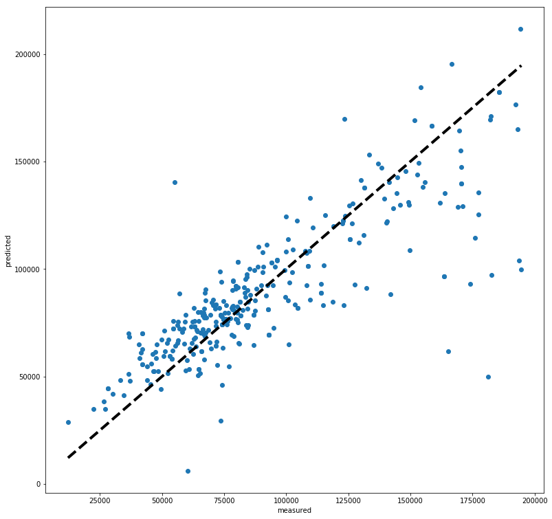

```python
fig, ax = plt.subplots(figsize=(13,13))
ax.scatter(y_test, y_predicted)
ax.plot([y_test.min(), y_test.max()], [y_test.min(), y_test.max()], 'k--', lw=4)
ax.set_xlabel('measured')
ax.set_ylabel('predicted')
plt.show()
```

```python
print('Intercept is : \n', reg1.intercept_)
print('Slopes are: \n', reg1.coef_)
#print('Variance score: {} \n'.format(reg1.score(x_test, y_test)))
```

```
Intercept is :
 [113988.31856489]
Slopes are:
 [[ 7.16259186e-01 -1.62620756e+00 -2.66361924e+01  7.03497329e-01
   1.37422868e+00 -1.90477141e-01  2.68267762e+01 -9.76045862e-01
   1.93842613e+00  7.13222306e-03  1.22380514e-02 -9.31747067e-03
  -1.21686558e-02  9.90623155e-02  1.09904670e-01  2.50286967e+00
   3.53804220e-01  9.90623155e-02  1.09904670e-01  2.50286967e+00
   3.53804220e-01  9.90623155e-02  1.09904670e-01 -2.72810486e+00
  -2.08335839e-01  9.90623155e-02  1.09904670e-01 -2.72810486e+00
  -2.08335839e-01 -4.18839620e+00  2.28161295e+03  1.28416953e+03
   6.86627915e+01 -1.53521768e+02 -1.31477569e+03 -3.75457932e+02
  -2.60320301e+03 -8.15572291e+03  1.93842613e+00  3.26899047e+00]]
```

Given the volume of data and the fact that there were considerable amount of missing values, I believe the R-square value of 0.68 is very decent and that a good model has been obtained.

Upon trying various different permutations on the dependent variables, the lowest MSE was obtained in this case of value 495959838.95